# FADN2Footprint — Validation Report

Comparison of package estimates with literature values

Author

Sarah HUET & Valentin BELLASSEN

Published

October 9, 2026

# Setup

```r
library(dplyr)
library(tidyr)
library(stringr)
library(gt)

library(ggplot2)

devtools::load_all("../../")
#library(FADN2Footprint)
```

# Purpose

This report compares the outputs of `FADN2Footprint` (v1.1.0) against published literature ranges. An estimate is flagged **in range** if it falls within the literature min–max, **within tolerance** if the relative deviation from the literature midpoint is below a per-indicator threshold, or **out of range** otherwise.

# Produce package estimates

```
FADN dataset loaded: 26682 farm-year observations
```

```
Countries covered: FRA
```

```
Years covered: 2018, 2019, 2020, 2021
```

```r
object = my_object_GHGE

# Crops
summary(object@crop)
```

```
      ID                YEAR             COUNTRY          FADN_code_letter
 Length:113744      Length:113744      Length:113744      Length:113744
 Class :character   Class :character   Class :character   Class :character
 Mode  :character   Mode  :character   Mode  :character   Mode  :character




      ENA                IRA                SV                TO
 Min.   : 0.00000   Min.   :  0.000   Min.   :      0   Min.   :-194600
 1st Qu.: 0.00000   1st Qu.:  0.000   1st Qu.:      0   1st Qu.:      0
 Median : 0.00000   Median :  0.000   Median :   4168   Median :   6647
 Mean   : 0.02121   Mean   :  1.458   Mean   :  40850   Mean   :  42906
 3rd Qu.: 0.00000   3rd Qu.:  0.000   3rd Qu.:  27651   3rd Qu.:  30240
 Max.   :92.50000   Max.   :607.280   Max.   :4862533   Max.   :4924968
 NA's   :242        NA's   :242       NA's   :242       NA's   :242
       CV            area_ha           prod_t            sales_t
 Min.   :   0.0   Min.   :  0.00   Min.   :    0.00   Min.   :    0.000
 1st Qu.:   0.0   1st Qu.:  4.34   1st Qu.:   24.49   1st Qu.:    0.000
 Median :   0.0   Median : 11.28   Median :   78.85   Median :    7.681
 Mean   : 154.6   Mean   : 21.93   Mean   :  225.27   Mean   :  150.888
 3rd Qu.:   0.0   3rd Qu.: 26.82   3rd Qu.:  233.51   3rd Qu.:  101.820
 Max.   :3555.0   Max.   :950.00   Max.   :16413.80   Max.   :16413.800
 NA's   :113721                                       NA's   :1856
 land_use_type        species              yield              NUTS0
 Length:113744      Length:113744      Min.   :    0.000   Length:113744
 Class :character   Class :character   1st Qu.:    4.643   Class :character
 Mode  :character   Mode  :character   Median :    6.639   Mode  :character
                                       Mean   :   14.358
                                       3rd Qu.:    9.424
                                       Max.   :10133.333

    NUTS1              NUTS2           default_forage_yield default_forage_prod
 Length:113744      Length:113744      Mode :logical        Mode :logical
 Class :character   Class :character   FALSE:77429          FALSE:77429
 Mode  :character   Mode  :character   TRUE :36315          TRUE :36315




 default_crop_yield default_crop_prod default_sales_to_prod
 Mode :logical      Mode :logical     Mode :logical
 FALSE:106991       FALSE:106991      FALSE:113709
 TRUE :6753         TRUE :6753        TRUE :35




 default_avrg_yield_crop  sum_area_ha       sum_prod_t      keep_sup5pc
 Mode :logical           Min.   :  0.01   Min.   :    0.0   Mode:logical
 FALSE:110791            1st Qu.: 52.90   1st Qu.:  420.6   TRUE:113744
 TRUE :2953              Median :100.88   Median :  749.5
                         Mean   :118.84   Mean   : 1174.8
                         3rd Qu.:161.56   3rd Qu.: 1346.5
                         Max.   :950.00   Max.   :26566.9
```

```r
(object@crop |>
    dplyr::filter(is.na(prod_t)))
```

```
# A tibble: 0 × 27
# ℹ 27 variables: ID <chr>, YEAR <chr>, COUNTRY <chr>, FADN_code_letter <chr>,
#   ENA <dbl>, IRA <dbl>, SV <dbl>, TO <dbl>, CV <dbl>, area_ha <dbl>,
#   prod_t <dbl>, sales_t <dbl>, land_use_type <chr>, species <chr>,
#   yield <dbl>, NUTS0 <chr>, NUTS1 <chr>, NUTS2 <chr>,
#   default_forage_yield <lgl>, default_forage_prod <lgl>,
#   default_crop_yield <lgl>, default_crop_prod <lgl>,
#   default_sales_to_prod <lgl>, default_avrg_yield_crop <lgl>, …
```

```r
#sort(table(object@crop |> filter(is.na(prod_t)) |> pull(FADN_code_letter)), decreasing = TRUE)
#table(object@crop |> filter(is.na(prod_t)) |> pull(keep_sup5pc))
#
#
## GHGE crops
#
summary(object@footprints$GHGE$GHGE_crops)
```

```
      ID                YEAR             COUNTRY          FADN_code_letter
 Length:113744      Length:113744      Length:113744      Length:113744
 Class :character   Class :character   Class :character   Class :character
 Mode  :character   Mode  :character   Mode  :character   Mode  :character




    area_ha           prod_t          N2O_d_kgCO2e    N2O_ATD_kgCO2e
 Min.   :  0.00   Min.   :    0.00   Min.   :     0   Min.   :    0.0
 1st Qu.:  4.34   1st Qu.:   24.49   1st Qu.:  2367   1st Qu.:  171.7
 Median : 11.28   Median :   78.85   Median :  8342   Median :  679.9
 Mean   : 21.93   Mean   :  225.27   Mean   : 18204   Mean   : 1599.1
 3rd Qu.: 26.82   3rd Qu.:  233.51   3rd Qu.: 23028   3rd Qu.: 2031.9
 Max.   :950.00   Max.   :16413.80   Max.   :650359   Max.   :48278.0

  N2O_L_kgCO2e      ghg_ferti_prod_kgCO2e ghg_heat_fuel_kgCO2e
 Min.   :     0.0   Min.   :     0.0      Min.   :      0
 1st Qu.:   931.6   1st Qu.:   242.7      1st Qu.:      0
 Median :  3160.3   Median :  2383.4      Median :      0
 Mean   :  7035.3   Mean   :  8220.8      Mean   :   1289
 3rd Qu.:  8840.7   3rd Qu.:  8590.6      3rd Qu.:      0
 Max.   :284489.0   Max.   :322770.8      Max.   :4270760
                                          NA's   :25
 ghg_diesel_tillage_kgCO2e ghg_diesel_remain_kgCO2e ghg_elec_kgCO2e
 Min.   :     0.0          Min.   :    0.0          Min.   :    0.00
 1st Qu.:   656.4          1st Qu.:    0.0          1st Qu.:    0.00
 Median :  3402.6          Median :  163.7          Median :   13.12
 Mean   :  7526.2          Mean   : 1373.5          Mean   :  242.05
 3rd Qu.:  9374.5          3rd Qu.: 1427.0          3rd Qu.:  140.37
 Max.   :254249.4          Max.   :52535.9          Max.   :42073.40
 NA's   :25                NA's   :25               NA's   :25
 total_ghg_crop_kgCO2e N2O_d_kgCO2e_per_ha N2O_d_kgCO2e_per_t
 Min.   :      0       Min.   :7.064e+00   Min.   :     0.06
 1st Qu.:   7933       1st Qu.:4.021e+02   1st Qu.:    54.51
 Median :  23255       Median :7.656e+02   Median :    99.13
 Mean   :  45488       Mean   :9.405e+02   Mean   :   143.55
 3rd Qu.:  56175       3rd Qu.:1.109e+03   3rd Qu.:   150.78
 Max.   :4431669       Max.   :2.793e+05   Max.   :515127.08
                                           NA's   :1517
```

[output cut: 41 more lines]

```
 Min.   :    0.000      Min.   :    0.000     Min.   :2.546e+01
 1st Qu.:    0.000      1st Qu.:    0.000     1st Qu.:1.117e+03
 Median :    1.349      Median :    0.160     Median :2.169e+03
 Mean   :   44.060      Mean   :    4.373     Mean   :3.457e+03
 3rd Qu.:   11.139      3rd Qu.:    1.463     3rd Qu.:3.211e+03
 Max.   :28675.051      Max.   :48042.746     Max.   :1.071e+06
 NA's   :25             NA's   :1517
 total_ghg_crop_kgCO2e_per_t
 Min.   :6.070e+00
 1st Qu.:1.490e+02
 Median :2.682e+02
 Mean   :5.242e+02
 3rd Qu.:4.589e+02
 Max.   :2.452e+06
 NA's   :1517
```

```r
#
object@footprints$GHGE$GHGE_crops |>
  dplyr::filter(!is.finite(N2O_d_kgCO2e_per_t)) #|> View()
```

```
# A tibble: 1,517 × 33
   ID            YEAR  COUNTRY FADN_code_letter area_ha prod_t N2O_d_kgCO2e
   <chr>         <chr> <chr>   <chr>              <dbl>  <dbl>        <dbl>
 1 515000000728  2018  FRA     CNURS               3.23      0        546.
 2 515000000340  2018  FRA     CFLWUG              1         0         80.2
 3 515000000340  2018  FRA     CFLW                1         0         80.2
 4 515000000247  2018  FRA     CFLWCUT             6         0        481.
 5 515000000247  2018  FRA     CFLWUG              6         0        481.
 6 515000000853  2018  FRA     CFLWUG              2.02      0        162.
 7 515000000853  2018  FRA     CFLW                2.02      0        162.
 8 515000000929  2018  FRA     CNURS               9.62      0       1334.
 9 515000000909  2018  FRA     CNURS               6.85      0        549.
10 5650000006622 2018  FRA     CNURS               0.5       0         40.1
# ℹ 1,507 more rows
# ℹ 26 more variables: N2O_ATD_kgCO2e <dbl>, N2O_L_kgCO2e <dbl>,
#   ghg_ferti_prod_kgCO2e <dbl>, ghg_heat_fuel_kgCO2e <dbl>,
#   ghg_diesel_tillage_kgCO2e <dbl>, ghg_diesel_remain_kgCO2e <dbl>,
#   ghg_elec_kgCO2e <dbl>, total_ghg_crop_kgCO2e <dbl>,
#   N2O_d_kgCO2e_per_ha <dbl>, N2O_d_kgCO2e_per_t <dbl>,
#   N2O_ATD_kgCO2e_per_ha <dbl>, N2O_ATD_kgCO2e_per_t <dbl>, …
```

```r
#sort(table(object@footprints$GHGE$GHGE_crops |> filter(is.na(prod_t)) |> pull(FADN_code_letter)), decreasing = TRUE)
```

# Literature references

```r
# TOTAL GHGE ----

lit_GHGE_total <- readxl::read_excel(
  "../../inst/validation/validation_references.xlsx",
  sheet = "summary_total_GHGE",
  col_types = c("text", "numeric", "numeric", "text", "text")
) |>
  # filter for references with both per ha and per t
  dplyr::filter(GHGE_kgCO2e_kg >0
                | GHGE_kgCO2e_ha >0) |>
  # filter for crops, meat, milk, and eggs
  dplyr::filter(grepl("wheat|maize_grain|rapeseed|milk|meat|eggs", product)) |>
  # filter values for France if present or EU otherwise for each product
  dplyr::group_by(product) |>
  dplyr::filter(
    if (any(grepl("France", area))) grepl("France", area) else TRUE
  ) |>
  dplyr::ungroup() |>
  # add set
  dplyr::mutate(set = "GHG Emissions")

# COMPONENTS OF GHGE ----

lit_GHGE_components <- readxl::read_excel(
  "../../inst/validation/validation_references.xlsx",
  sheet = "summary_share_components"
) |>
  # filter for crops, meat and milk
  dplyr::filter(grepl("wheat|maize_grain|rapeseed|milk|meat|eggs", product)) |>
  # filter values for France if present or EU otherwise for each product and component
  dplyr::group_by(product, Harmonized_Category) |>
  dplyr::filter(
    if (any(grepl("France", area))) grepl("France", area) else TRUE
  ) |>
  dplyr::ungroup() |>
  # remove unclassified components
  dplyr::filter(!is.na(Harmonized_Category)) |>
  # sum up by product,Harmonized_Category,sheet,area
  dplyr::summarise(
    dplyr::across(
      c(GHGE_kgCO2e_ha,GHGE_kgCO2e_kg),
      ~ sum(.x)
    ),
    .by = c('product','Harmonized_Category','sheet','area')
  ) |>
  # add set
  dplyr::mutate(set = "GHG Emissions")

cat("Literature (total GHGE) loaded:", nrow(lit_GHGE_total), "rows\n")
```

```
Literature (total GHGE) loaded: 102 rows
```

```r
cat("Literature (components of GHGE) loaded:", nrow(lit_GHGE_components), "rows\n")
```

```
Literature (components of GHGE) loaded: 49 rows
```

```r
lit_agri_pract <- readxl::read_excel(
  "../../inst/validation/validation_references.xlsx",
  sheet = "summary_agri_practices"
)

# add EPK averages for wheat fertilization ----
tmp = data_extra$PKGC_N_ferti |>
  dplyr::filter(EPK_ferti_crop_name == "Ble_tendre" & ORGANIC == 0) |>
  dplyr::select(N_min,Nmin_sd_w,N_org,Norg_sd_w)

lit_agri_pract <- lit_agri_pract |>
  dplyr::bind_rows(
    tibble::tibble(
      indicator = c("mineral fertilization", "organic fertilizer"),
      unit = "kg N / ha",
      product = "wheat",
      area = "France",
      lit_midpoint = c(tmp$N_min, tmp$N_org),
      lit_min = 0,
      lit_max = c((tmp$N_min + tmp$Nmin_sd_w), (tmp$N_org + tmp$Norg_sd_w)),
      #tolerance_pct = "More than half\n&\nLess than twice",
      lit_source = "EPK 2017"
    )
  ) |>
  # add set
  dplyr::mutate(set = "Agricultural practices")


cat("Literature (agricultural practices) loaded:", nrow(lit_agri_pract), "rows\n")
```

```
Literature (agricultural practices) loaded: 16 rows
```

```r
lit_GHGE_total |> arrange(set,product,sheet) |> gt()
```

| product | GHGE_kgCO2e_kg | GHGE_kgCO2e_ha | area | sheet | set |
| --- | --- | --- | --- | --- | --- |
| cattle_meat | 12.0000000 | 9931.000 | France | CAP2ER_2025_BV_E_JB_viande | GHG Emissions |
| cattle_meat | 18.1000000 | 4496.000 | France | CAP2ER_2025_BV_NE_boeufs | GHG Emissions |
| cattle_meat | 14.5000000 | 6460.620 | France | Extract_Agribalyse | GHG Emissions |
| eggs | 2.8800000 | NA | France | Clune_2017 | GHG Emissions |
| eggs | 3.1900000 | NA | France | Clune_2017 | GHG Emissions |
| eggs | 1.1800000 | 5063.667 | France | Extract_Agribalyse | GHG Emissions |
| maize_grain | 0.3560000 | 3684.997 | France | Extract_Agribalyse | GHG Emissions |
| meat_chicken | 2.7090909 | NA | France | Clune_2017 | GHG Emissions |
| meat_chicken | 2.9731169 | NA | France | Clune_2017 | GHG Emissions |
| meat_chicken | 3.5964935 | NA | France | Clune_2017 | GHG Emissions |
| meat_chicken | 4.2698701 | NA | France | Clune_2017 | GHG Emissions |
| meat_chicken | 4.6166667 | NA | France | Clune_2017 | GHG Emissions |
| meat_chicken | 5.3511111 | NA | France | Clune_2017 | GHG Emissions |
| meat_chicken | 5.3607792 | NA | France | Clune_2017 | GHG Emissions |
| meat_chicken | 5.3696296 | NA | France | Clune_2017 | GHG Emissions |
| meat_chicken | 5.9251852 | NA | France | Clune_2017 | GHG Emissions |
| meat_chicken | 6.1103704 | NA | France | Clune_2017 | GHG Emissions |
| meat_chicken | 1.9300000 | 6426.770 | France | Extract_Agribalyse | GHG Emissions |
| meat_pork | 2.9740000 | 4310.000 | France | Bellassen_2021 | GHG Emissions |
| meat_pork | 2.3000000 | 4240.000 | France | Chiriaco_2022 | GHG Emissions |
| meat_pork | 3.7865116 | NA | France | Clune_2017 | GHG Emissions |
| meat_pork | 3.8330233 | NA | France | Clune_2017 | GHG Emissions |
| meat_pork | 4.0190698 | NA | France | Clune_2017 | GHG Emissions |
| meat_pork | 4.2000000 | NA | France | Clune_2017 | GHG Emissions |
| meat_pork | 4.2516279 | NA | France | Clune_2017 | GHG Emissions |
| meat_pork | 4.3213953 | NA | France | Clune_2017 | GHG Emissions |
| meat_pork | 4.6702326 | NA | France | Clune_2017 | GHG Emissions |
| meat_pork | 5.0655814 | NA | France | Clune_2017 | GHG Emissions |
| meat_pork | 5.1000000 | NA | France | Clune_2017 | GHG Emissions |
| meat_pork | 5.1120930 | NA | France | Clune_2017 | GHG Emissions |

[output cut: 72 more lines]

```r
lit_GHGE_components |> arrange(set,product,Harmonized_Category,sheet) |> gt()
```

| product | Harmonized_Category | sheet | area | GHGE_kgCO2e_ha | GHGE_kgCO2e_kg | set |
| --- | --- | --- | --- | --- | --- | --- |
| cattle_meat | Energy Use (Diesel/Elec) | CAP2ER_2025_BV_E_JB_viande | France | 413.79167 | 0.50000000 | GHG Emissions |
| cattle_meat | Energy Use (Diesel/Elec) | CAP2ER_2025_BV_NE_boeufs | France | 298.07735 | 1.20000000 | GHG Emissions |
| cattle_meat | Enteric Fermentation | CAP2ER_2025_BV_E_JB_viande | France | 6041.35833 | 7.30000000 | GHG Emissions |
| cattle_meat | Enteric Fermentation | CAP2ER_2025_BV_NE_boeufs | France | 3104.97238 | 12.50000000 | GHG Emissions |
| cattle_meat | Fertilizer Production | CAP2ER_2025_BV_E_JB_viande | France | 165.51667 | 0.20000000 | GHG Emissions |
| cattle_meat | Fertilizer Production | CAP2ER_2025_BV_NE_boeufs | France | 24.83978 | 0.10000000 | GHG Emissions |
| cattle_meat | Field N2O Emissions | CAP2ER_2025_BV_E_JB_viande | France | 2234.47500 | 2.70000000 | GHG Emissions |
| cattle_meat | Field N2O Emissions | CAP2ER_2025_BV_NE_boeufs | France | 372.59669 | 1.50000000 | GHG Emissions |
| cattle_meat | Manure Management | CAP2ER_2025_BV_E_JB_viande | France | 993.10000 | 1.20000000 | GHG Emissions |
| cattle_meat | Manure Management | CAP2ER_2025_BV_NE_boeufs | France | 695.51381 | 2.80000000 | GHG Emissions |
| eggs | Energy Use (Diesel/Elec) | Lesschen_2011_compo | Europe | 333.33333 | NA | GHG Emissions |
| eggs | Enteric Fermentation | Lesschen_2011_compo | Europe | 0.00000 | NA | GHG Emissions |
| eggs | Fertilizer Production | Lesschen_2011_compo | Europe | 166.66667 | NA | GHG Emissions |
| eggs | Field N2O Emissions | Lesschen_2011_compo | Europe | 833.33333 | NA | GHG Emissions |
| eggs | Manure Management | Lesschen_2011_compo | Europe | 333.33333 | NA | GHG Emissions |
| eggs | Other Inputs & Processes | Lesschen_2011_compo | Europe | 166.66667 | NA | GHG Emissions |
| meat_chicken | Energy Use (Diesel/Elec) | Lesschen_2011_compo | Europe | 300.00000 | NA | GHG Emissions |
| meat_chicken | Enteric Fermentation | Lesschen_2011_compo | Europe | 0.00000 | NA | GHG Emissions |
| meat_chicken | Fertilizer Production | Lesschen_2011_compo | Europe | 300.00000 | NA | GHG Emissions |
| meat_chicken | Field N2O Emissions | Lesschen_2011_compo | Europe | 700.00000 | NA | GHG Emissions |
| meat_chicken | Manure Management | Lesschen_2011_compo | Europe | 300.00000 | NA | GHG Emissions |
| meat_chicken | Other Inputs & Processes | Lesschen_2011_compo | Europe | 200.00000 | NA | GHG Emissions |
| meat_pork | Energy Use (Diesel/Elec) | Bellassen_2021 | France | 206.00000 | 0.14200000 | GHG Emissions |
| meat_pork | Enteric Fermentation | Bellassen_2021 | France | 181.00000 | 0.12500000 | GHG Emissions |
| meat_pork | Fertilizer Production | Bellassen_2021 | France | 499.00000 | 0.34400000 | GHG Emissions |
| meat_pork | Field N2O Emissions | Bellassen_2021 | France | 207.00000 | 0.14300000 | GHG Emissions |
| meat_pork | Manure Management | Bellassen_2021 | France | 1233.00000 | 0.85100000 | GHG Emissions |
| meat_pork | Other Inputs & Processes | Bellassen_2021 | France | 177.00000 | 0.12200000 | GHG Emissions |
| milk | Energy Use (Diesel/Elec) | Bellassen_2021 | France | 250.00000 | 0.04500000 | GHG Emissions |
| milk | Energy Use (Diesel/Elec) | CAP2ER_2025_bovin_laitier | France | 549.91176 | 0.07000000 | GHG Emissions |
| milk | Enteric Fermentation | Bellassen_2021 | France | 3423.00000 | 0.61500000 | GHG Emissions |
| milk | Enteric Fermentation | CAP2ER_2025_bovin_laitier | France | 4477.85294 | 0.57000000 | GHG Emissions |
| milk | Fertilizer Production | Bellassen_2021 | France | 228.00000 | 0.04100000 | GHG Emissions |
| milk | Fertilizer Production | CAP2ER_2025_bovin_laitier | France | 157.11765 | 0.02000000 | GHG Emissions |
| milk | Field N2O Emissions | Bellassen_2021 | France | NA | NA | GHG Emissions |
| milk | Field N2O Emissions | CAP2ER_2025_bovin_laitier | France | 1649.73529 | 0.21000000 | GHG Emissions |
| milk | Land Use Change / Soil Carbon | Agribalyse_2025 | France | NA | 0.11525083 | GHG Emissions |
| milk | Manure Management | Bellassen_2021 | France | NA | NA | GHG Emissions |
| milk | Manure Management | CAP2ER_2025_bovin_laitier | France | 1099.82353 | 0.14000000 | GHG Emissions |
| milk | Other Inputs & Processes | Bellassen_2021 | France | 122.00000 | 0.02200000 | GHG Emissions |
| wheat | Energy Use (Diesel/Elec) | Bellassen_2021 | France | 228.00000 | 0.06200000 | GHG Emissions |
| wheat | Fertilizer Production | Bamber_2025_fig1 | France | 2623.30000 | 0.37000000 | GHG Emissions |
| wheat | Fertilizer Production | Bellassen_2021 | France | 871.00000 | 0.11500000 | GHG Emissions |
| wheat | Field N2O Emissions | Bamber_2025_fig1 | France | 1559.80000 | 0.22000000 | GHG Emissions |
| wheat | Field N2O Emissions | Bamber_2025_sup_tab5 | France | 3587.54000 | 0.50600000 | GHG Emissions |
| wheat | Field N2O Emissions | Bellassen_2021 | France | NA | NA | GHG Emissions |
| wheat | Land Use Change / Soil Carbon | Agribalyse_2025 | France | NA | 0.07210423 | GHG Emissions |
| wheat | Land Use Change / Soil Carbon | Bamber_2025_sup_tab5 | France | 609.74000 | 0.08600000 | GHG Emissions |
| wheat | Other Inputs & Processes | Bellassen_2021 | France | 216.00000 | 0.02800000 | GHG Emissions |

```r
lit_agri_pract |> arrange(set,indicator) |> gt()
```

| indicator | unit | product | area | lit_midpoint | lit_min | lit_max | lit_source | set |
| --- | --- | --- | --- | --- | --- | --- | --- | --- |
| DMI | kg / head / day | dairy_cows | Germany | NA | 8 | 24.0000 | Flachowsky_2002 | Agricultural practices |
| GE | MJ / head / day | dairy_cows | France | 3.080000e+02 | NA | NA | Bellassen_2021 | Agricultural practices |
| Nex | kg N / head / year | dairy_cows | France | 1.159100e+02 | NA | NA | UNFCCC_2020 | Agricultural practices |
| feed_Energy rich feed | percent | dairy_cows | Europe | 5.524862e-03 | NA | NA | Lesschen_2011 | Agricultural practices |
| feed_Feed cereals | percent | dairy_cows | Europe | 2.569061e-01 | NA | NA | Lesschen_2011 | Agricultural practices |
| feed_Fodder maize | percent | dairy_cows | Europe | 7.458564e-02 | NA | NA | Lesschen_2011 | Agricultural practices |
| feed_Fodder root crops | percent | dairy_cows | Europe | 2.762431e-03 | NA | NA | Lesschen_2011 | Agricultural practices |
| feed_Grass | percent | dairy_cows | Europe | 2.900552e-01 | NA | NA | Lesschen_2011 | Agricultural practices |
| feed_Other feed | percent | dairy_cows | Europe | 1.104972e-02 | NA | NA | Lesschen_2011 | Agricultural practices |
| feed_Other fodder | percent | dairy_cows | Europe | 1.602210e-01 | NA | NA | Lesschen_2011 | Agricultural practices |
| feed_Protein rich feed | percent | dairy_cows | Europe | 1.988950e-01 | NA | NA | Lesschen_2011 | Agricultural practices |
| first_calving_age | month | dairy_cows | France | 3.000000e+01 | 27 | 32.0000 | CAP2ER_2025 | Agricultural practices |
| mineral fertilization | kg N / ha | wheat | France | 1.657839e+02 | 0 | 209.9956 | EPK 2017 | Agricultural practices |
| organic fertilizer | kg N / ha | wheat | France | 1.058427e+01 | 0 | 48.5810 | EPK 2017 | Agricultural practices |
| renewal_rate | percent | dairy_cows | France | 3.600000e+01 | 32 | 36.0000 | CAP2ER_2025 | Agricultural practices |
| share_concent | percent | dairy_cows | Germany | NA | 0 | 40.0000 | Flachowsky_2002 | Agricultural practices |

```r
lit_table = dplyr::bind_rows(
  lit_agri_pract,
  lit_GHGE_total |>
    dplyr::mutate(GHGE_kgCO2e_t = GHGE_kgCO2e_kg*10^3) |>
    tidyr::pivot_longer(cols = c(GHGE_kgCO2e_ha,GHGE_kgCO2e_t),
                        names_to = "indicator") |>
    dplyr::filter(!is.na(value)) |>
    dplyr::summarise(lit_midpoint = mean(value),
                     lit_min = min(value),
                     lit_max = max(value),
                     lit_source = paste0(unique(sheet),collapse = "; "),
                     area = paste0(unique(area),collapse = "; "),
                     .by = c('set', 'indicator', 'product')) |>
    dplyr::mutate(
      unit = ifelse(grepl("_ha",indicator),"kgCO2e_per_ha","kgCO2e_per_t")
    )
) |>
  dplyr::bind_rows(
    lit_GHGE_components |>
      dplyr::mutate(GHGE_kgCO2e_t = GHGE_kgCO2e_kg*10^3) |>
      tidyr::pivot_longer(cols = c(GHGE_kgCO2e_ha,GHGE_kgCO2e_t),
                          names_to = "indicator") |>
      dplyr::filter(!is.na(value)) |>
      dplyr::mutate(indicator = paste(indicator,Harmonized_Category,sep = "__")) |>
      dplyr::summarise(lit_midpoint = mean(value, na.rm = T),
                       lit_min = min(value, na.rm = T),
                       lit_max = max(value, na.rm = T),
                       lit_source = paste0(unique(sheet),collapse = "; "),
                       area = paste0(unique(area),collapse = "; "),
                       .by = c('set', 'indicator', 'product')) |>
      dplyr::mutate(
        unit = ifelse(grepl("_ha",indicator),"kgCO2e_per_ha","kgCO2e_per_t")
      )

  ) |>
  # arrange columns
  dplyr::select(set, indicator, unit, product, area, lit_midpoint, lit_min, lit_max, lit_source)
```

```r
# add global GHGE at farm scale from ADEME data base of carbon diagnosis
ADEME_desc_stat_TF <- read.csv("ADEME_desc_stat_TF.csv")

lit_table <- dplyr::bind_rows(
  lit_table,
  ADEME_desc_stat_TF |>
    dplyr::filter(exploitation_otex %in% c(1500, 4500, 4600)) |>
    dplyr::mutate(
      set = "GHG Emissions",
      indicator = dplyr::case_when(
        variable == "emissions_ges_totales_exploitation" ~ "pseudofarm_total_ghge_kgCO2e",
        variable == "emissions_ges_co2" ~ "pseudofarm_total_CO2_kgCO2e",
        variable == "emissions_ges_ch4" ~ "pseudofarm_total_CH4_kgCO2e",
        variable == "emissions_ges_n2o" ~ "pseudofarm_total_N2O_kgCO2e",

        variable == "emissions_ges_totales_exploitation_per_ha" ~ "pseudofarm_total_ghge_kgCO2e_per_ha",
        variable == "emissions_ges_co2_per_ha" ~ "pseudofarm_total_CO2_kgCO2e_per_ha",
        variable == "emissions_ges_ch4_per_ha" ~ "pseudofarm_total_CH4_kgCO2e_per_ha",
        variable == "emissions_ges_n2o_per_ha" ~ "pseudofarm_total_N2O_kgCO2e_per_ha",

        variable == "emissions_ges_totales_exploitation_per_LU" ~ "pseudofarm_total_ghge_kgCO2e_per_LU",
        variable == "emissions_ges_co2_per_LU" ~ "pseudofarm_total_CO2_kgCO2e_per_LU",
        variable == "emissions_ges_ch4_per_LU" ~ "pseudofarm_total_CH4_kgCO2e_per_LU",
        variable == "emissions_ges_n2o_per_LU" ~ "pseudofarm_total_N2O_kgCO2e_per_LU"
      ),
      unit = dplyr::case_when(
        grepl("_per_ha$",variable) ~ "kgCO2e_per_ha",
        grepl("_per_LU$",variable) ~ "kgCO2e_per_LU",
        .default = "kgCO2e"
      ),
      product = dplyr::case_when(
        exploitation_otex == 1500 ~ "Field crop farms",
        exploitation_otex == 4500 ~ "Dairy farms",
        exploitation_otex == 4600 ~ "Beef farms"
      ),
      area = "France",
      lit_midpoint = mean,
      lit_min = pmax(mean - sd, 0, na.rm = T),
      lit_max = mean + sd,
      lit_source = "ADEME data base"
    ) |>
    dplyr::filter(!is.na(indicator)) |>
    # arrange columns
    dplyr::select(set, indicator, unit, product, area, lit_midpoint, lit_min, lit_max, lit_source)
)
```

```r
# Display

lit_table |> arrange(set, product, indicator) |> gt()
```

| set | indicator | unit | product | area | lit_midpoint | lit_min | lit_max | lit_source |
| --- | --- | --- | --- | --- | --- | --- | --- | --- |
| Agricultural practices | DMI | kg / head / day | dairy_cows | Germany | NA | 8.00000 | 24.0000 | Flachowsky_2002 |
| Agricultural practices | GE | MJ / head / day | dairy_cows | France | 3.080000e+02 | NA | NA | Bellassen_2021 |
| Agricultural practices | Nex | kg N / head / year | dairy_cows | France | 1.159100e+02 | NA | NA | UNFCCC_2020 |
| Agricultural practices | feed_Energy rich feed | percent | dairy_cows | Europe | 5.524862e-03 | NA | NA | Lesschen_2011 |
| Agricultural practices | feed_Feed cereals | percent | dairy_cows | Europe | 2.569061e-01 | NA | NA | Lesschen_2011 |
| Agricultural practices | feed_Fodder maize | percent | dairy_cows | Europe | 7.458564e-02 | NA | NA | Lesschen_2011 |
| Agricultural practices | feed_Fodder root crops | percent | dairy_cows | Europe | 2.762431e-03 | NA | NA | Lesschen_2011 |
| Agricultural practices | feed_Grass | percent | dairy_cows | Europe | 2.900552e-01 | NA | NA | Lesschen_2011 |
| Agricultural practices | feed_Other feed | percent | dairy_cows | Europe | 1.104972e-02 | NA | NA | Lesschen_2011 |
| Agricultural practices | feed_Other fodder | percent | dairy_cows | Europe | 1.602210e-01 | NA | NA | Lesschen_2011 |
| Agricultural practices | feed_Protein rich feed | percent | dairy_cows | Europe | 1.988950e-01 | NA | NA | Lesschen_2011 |
| Agricultural practices | first_calving_age | month | dairy_cows | France | 3.000000e+01 | 27.00000 | 32.0000 | CAP2ER_2025 |
| Agricultural practices | renewal_rate | percent | dairy_cows | France | 3.600000e+01 | 32.00000 | 36.0000 | CAP2ER_2025 |
| Agricultural practices | share_concent | percent | dairy_cows | Germany | NA | 0.00000 | 40.0000 | Flachowsky_2002 |
| Agricultural practices | mineral fertilization | kg N / ha | wheat | France | 1.657839e+02 | 0.00000 | 209.9956 | EPK 2017 |
| Agricultural practices | organic fertilizer | kg N / ha | wheat | France | 1.058427e+01 | 0.00000 | 48.5810 | EPK 2017 |
| GHG Emissions | pseudofarm_total_CH4_kgCO2e | kgCO2e | Beef farms | France | 5.650292e+05 | 149004.67848 | 981053.6994 | ADEME data base |
| GHG Emissions | pseudofarm_total_CH4_kgCO2e_per_LU | kgCO2e_per_LU | Beef farms | France | 6.068761e+03 | 3023.34879 | 9114.1740 | ADEME data base |
| GHG Emissions | pseudofarm_total_CH4_kgCO2e_per_ha | kgCO2e_per_ha | Beef farms | France | 3.791170e+03 | 1799.25649 | 5783.0826 | ADEME data base |
| GHG Emissions | pseudofarm_total_CO2_kgCO2e | kgCO2e | Beef farms | France | 1.394139e+05 | 0.00000 | 279913.2833 | ADEME data base |
| GHG Emissions | pseudofarm_total_CO2_kgCO2e_per_LU | kgCO2e_per_LU | Beef farms | France | 2.754659e+03 | 1024.27140 | 4485.0460 | ADEME data base |
| GHG Emissions | pseudofarm_total_CO2_kgCO2e_per_ha | kgCO2e_per_ha | Beef farms | France | 9.269550e+02 | 117.28205 | 1736.6280 | ADEME data base |
| GHG Emissions | pseudofarm_total_N2O_kgCO2e | kgCO2e | Beef farms | France | 1.791052e+05 | 38286.92461 | 319923.5027 | ADEME data base |
| GHG Emissions | pseudofarm_total_N2O_kgCO2e_per_LU | kgCO2e_per_LU | Beef farms | France | 1.921015e+03 | 967.29462 | 2874.7362 | ADEME data base |
| GHG Emissions | pseudofarm_total_N2O_kgCO2e_per_ha | kgCO2e_per_ha | Beef farms | France | 1.156839e+03 | 574.28033 | 1739.3974 | ADEME data base |
| GHG Emissions | pseudofarm_total_ghge_kgCO2e | kgCO2e | Beef farms | France | 8.800293e+05 | 250148.26360 | 1509910.2414 | ADEME data base |
| GHG Emissions | pseudofarm_total_ghge_kgCO2e_per_LU | kgCO2e_per_LU | Beef farms | France | 1.067051e+04 | 6202.11892 | 15138.9085 | ADEME data base |
| GHG Emissions | pseudofarm_total_ghge_kgCO2e_per_ha | kgCO2e_per_ha | Beef farms | France | 5.863662e+03 | 2891.65022 | 8835.6742 | ADEME data base |
| GHG Emissions | pseudofarm_total_CH4_kgCO2e | kgCO2e | Dairy farms | France | 5.637815e+05 | 252026.65213 | 875536.3445 | ADEME data base |
| GHG Emissions | pseudofarm_total_CH4_kgCO2e_per_LU | kgCO2e_per_LU | Dairy farms | France | 4.389359e+03 | 3240.49492 | 5538.2227 | ADEME data base |

[output cut: 91 more lines]

# Package outputs

## Agricultural practices

### Quantity of mineral and organic N per hectare

We retrieve the average quantity of mineral nitrogen per hectare for different crops from Farm Survey Practices, and used it as an allocation key. We can now compare if the average per crops from the package output are close to the retrieved averages from these surveys.

```r
# select crop farms in France
tmp_object_crop = m_prune_farms(my_object_GHGE, TF8 == 1, COUNTRY == "FRA")

# Retrieve fertilization estimates for crops, filtering to common wheat only
tmp_nferti <- tmp_object_crop@practices$crops$N_ferti |>
  dplyr::filter(FADN_code_letter == "CWHTC")

my_ferti = tibble::tibble(
  indicator = c("mineral fertilization", "organic fertilizer"),
  unit = "kg N / ha",
  product = "wheat",
  estimate = c(mean(tmp_nferti$N_ferti_min, na.rm = T),
               mean(tmp_nferti$N_ferti_org, na.rm = T))
)
```

### DMI, GE and Nex per head of dairy cows

The package estimates the feed Dry Matter Intake (DMI) and Gross Energy (GE) supplied to livestock, and deduce the livestock N excretion rates (Nex). We can also estimate the Roughage-to-concentrate ratio (DM basis), %.

```r
# select dairy cattle farms in France
tmp_object_milk = m_prune_farms(my_object_GHGE, TF14 == "45", COUNTRY == "FRA")

# Retrieve model estimates
my_Nexcr <- tmp_object_milk@practices$herding$N_excretion$cattle |>
  # filter for dairy cows
  dplyr::filter(FADN_code_letter == "LCOWDAIR") |>
  # select variables
  dplyr::select(dplyr::all_of(tmp_object_milk@traceability$id_cols),
                DM_t_anim,
                GE_DMI_MJ_anim_day,GE_IPCC_MJ_anim_day,
                Nex_DMI_kgN_anim_y,Nex_IPCC_kgN_anim_y) |>
  # add share concent
  dplyr::left_join(
    tmp_object_milk@practices$herding$general |>
      # filter for dairy cows
      dplyr::filter(FADN_code_letter == "LCOWDAIR") |>
      dplyr::select(dplyr::all_of(tmp_object_milk@traceability$id_cols),
                    share_concent) |>
      # convert in percent
      dplyr::mutate(share_concent = share_concent*100),
    by = tmp_object_milk@traceability$id_cols
  )

# resume table
my_Nexcr_sumup <- my_Nexcr |>
  dplyr::summarise(dplyr::across(
    c(DM_t_anim,
      GE_DMI_MJ_anim_day,GE_IPCC_MJ_anim_day,
      Nex_DMI_kgN_anim_y,Nex_IPCC_kgN_anim_y,
      share_concent),
    list(
      mean = ~ round(mean(.x, na.rm = T),2),
      sd = ~ round(sd(.x, na.rm = T),2)
    ),
    .names = "{.col}_{.fn}"
  ))
```

### Rearing parameters

For dairy cows, we estimate different rearing parameters such as the age at first calving, the renewal rate, or the number of heifers to renew dairy cows.

```r
# Herd rearing parameters
herd_rear_param = f_herd_rearing_param_cattle(tmp_object_milk) |>
  dplyr::select(dplyr::all_of(tmp_object_milk@traceability$id_cols),
                t_1st_calve,rt_LCOWDAIR,LCOWDAIR_Qobs,LCOWDAIR_Fin) |>
  dplyr::mutate(
    # first_calving_age
    first_calving_age = t_1st_calve,
    # renewal_rate
    ## we convert first calving cow number into livestock unit using the heifer livestock unit coefficient
    renewal_rate = mean(LCOWDAIR_Fin*0.8 / LCOWDAIR_Qobs * 100,na.rm = T)
  )
```

### Yields

```r
mean(tmp_object_milk@output$other_herd_products |>
       dplyr::filter(output == "milk" & species == "cattle") |>
       dplyr::pull(yield))
```

```
[1] 6.840484
```

## GHGE

### GHGE crops

```r
# Retrieve GHGE estimates for crops, filtering to common wheat only
tmp_ghge_wheat <- tmp_object_crop@footprints$GHGE$GHGE_crops |>
  dplyr::filter(FADN_code_letter == "CWHTC")

(tmp_ghge_wheat)
```

```
# A tibble: 4,484 × 33
   ID           YEAR  COUNTRY FADN_code_letter area_ha prod_t N2O_d_kgCO2e
   <chr>        <chr> <chr>   <chr>              <dbl>  <dbl>        <dbl>
 1 515000000629 2018  FRA     CWHTC              141   1107        199029.
 2 515000000488 2018  FRA     CWHTC               41    234.        38978.
 3 515000000474 2018  FRA     CWHTC               39.8  272         13950.
 4 515000000479 2018  FRA     CWHTC               24.6  173.        27600.
 5 515000000868 2018  FRA     CWHTC               23.2  181.        23904.
 6 515000000862 2018  FRA     CWHTC               41.8  260.        12109.
 7 515000000895 2018  FRA     CWHTC               45.7  418.        51457.
 8 515000000826 2018  FRA     CWHTC               82.6  682.        98628.
 9 515000000754 2018  FRA     CWHTC               30.8  250.        35500.
10 515000000785 2018  FRA     CWHTC               17.5   10.5        2716.
# ℹ 4,474 more rows
# ℹ 26 more variables: N2O_ATD_kgCO2e <dbl>, N2O_L_kgCO2e <dbl>,
#   ghg_ferti_prod_kgCO2e <dbl>, ghg_heat_fuel_kgCO2e <dbl>,
#   ghg_diesel_tillage_kgCO2e <dbl>, ghg_diesel_remain_kgCO2e <dbl>,
#   ghg_elec_kgCO2e <dbl>, total_ghg_crop_kgCO2e <dbl>,
#   N2O_d_kgCO2e_per_ha <dbl>, N2O_d_kgCO2e_per_t <dbl>,
#   N2O_ATD_kgCO2e_per_ha <dbl>, N2O_ATD_kgCO2e_per_t <dbl>, …
```

```r
# Reshape to long format, keeping per-ha and per-t columns, dropping totals
tmp_ghge_wheat_compo_long <- tmp_ghge_wheat |>
  dplyr::select(
    dplyr::all_of(tmp_object_crop@traceability$id_cols),
    dplyr::matches("per_ha$|per_t$"),      # keep intensity estimates only
    -dplyr::matches("total_ghg")           # drop aggregated totals
  ) |>
  tidyr::pivot_longer(
    cols = dplyr::matches("per_ha$|per_t$"),
    names_to = "component"
  ) |>
  dplyr::mutate(
    # Map component names to standardised GHGE categories
    Harmonized_Category = case_when(
      str_detect(component, "N2O")        ~ "Field N2O Emissions",
      str_detect(component, "ferti_prod") ~ "Fertilizer Production",
      str_detect(component, "diesel|fuel|elec")~ "Energy Use (Diesel/Elec)",
      TRUE                                ~ "Other Inputs & Processes" # pesticides, seeds, etc.
    ),
    product = "wheat",
    # Build composite indicator label encoding unit type and GHGE category
    indicator = dplyr::case_when(
      grepl("per_ha$", component) ~ paste("GHGE_kgCO2e_ha", Harmonized_Category, sep = "__"),
      grepl("per_t$",  component) ~ paste("GHGE_kgCO2e_t",  Harmonized_Category, sep = "__")
    ),
    # Assign unit label based on denominator (area vs. product mass)
    unit = dplyr::case_when(
      grepl("per_ha$", component) ~ "kgCO2e_per_ha",
      grepl("per_t$",  component) ~ "kgCO2e_per_t"
    )
  )

# Aggregate: sum GHGE components within each farm × category × unit combination
tmp_ghge_wheat_compo <- tmp_ghge_wheat_compo_long |>
  dplyr::summarise(
    value = sum(value, na.rm = TRUE),
    .by = c(tmp_object_crop@traceability$id_cols, "product", "Harmonized_Category", "indicator", "unit")
  )
```

```r
# Retrieve GHGE estimates for crops, filtering to common maize only
tmp_ghge_maize <- tmp_object_crop@footprints$GHGE$GHGE_crops |>
  dplyr::filter(FADN_code_letter == "CMZ")

tmp_ghge_maize
```

```
# A tibble: 2,405 × 33
   ID           YEAR  COUNTRY FADN_code_letter area_ha prod_t N2O_d_kgCO2e
   <chr>        <chr> <chr>   <chr>              <dbl>  <dbl>        <dbl>
 1 515000000488 2018  FRA     CMZ                21    111.         17730.
 2 515000000474 2018  FRA     CMZ                 8.27  71.6         3335.
 3 515000000786 2018  FRA     CMZ                43.4  307.         40862.
 4 515000000787 2018  FRA     CMZ                 0.47   3.91         490.
 5 515000000735 2018  FRA     CMZ                 7     36.7         7041.
 6 515000000733 2018  FRA     CMZ                28.5  175.         50802.
 7 515000000732 2018  FRA     CMZ                 5.9   58.4         4687.
 8 515000000728 2018  FRA     CMZ                21.0  122.         15824.
 9 515000000301 2018  FRA     CMZ                10.5   53.7        10868.
10 515000000302 2018  FRA     CMZ                39.2  429.         39871.
# ℹ 2,395 more rows
# ℹ 26 more variables: N2O_ATD_kgCO2e <dbl>, N2O_L_kgCO2e <dbl>,
#   ghg_ferti_prod_kgCO2e <dbl>, ghg_heat_fuel_kgCO2e <dbl>,
#   ghg_diesel_tillage_kgCO2e <dbl>, ghg_diesel_remain_kgCO2e <dbl>,
#   ghg_elec_kgCO2e <dbl>, total_ghg_crop_kgCO2e <dbl>,
#   N2O_d_kgCO2e_per_ha <dbl>, N2O_d_kgCO2e_per_t <dbl>,
#   N2O_ATD_kgCO2e_per_ha <dbl>, N2O_ATD_kgCO2e_per_t <dbl>, …
```

```r
# Reshape to long format, keeping per-ha and per-t columns, dropping totals
tmp_ghge_maize_compo_long <- tmp_ghge_maize |>
  dplyr::select(
    dplyr::all_of(tmp_object_crop@traceability$id_cols),
    dplyr::matches("per_ha$|per_t$"),      # keep intensity estimates only
    -dplyr::matches("total_ghg")           # drop aggregated totals
  ) |>
  tidyr::pivot_longer(
    cols = dplyr::matches("per_ha$|per_t$"),
    names_to = "component"
  ) |>
  dplyr::mutate(
    # Map component names to standardised GHGE categories
    Harmonized_Category = case_when(
      str_detect(component, "N2O")        ~ "Field N2O Emissions",
      str_detect(component, "ferti_prod") ~ "Fertilizer Production",
      str_detect(component, "diesel|fuel|elec")~ "Energy Use (Diesel/Elec)",
      TRUE                                ~ "Other Inputs & Processes" # pesticides, seeds, etc.
    ),
    product = "maize_grain",
    # Build composite indicator label encoding unit type and GHGE category
    indicator = dplyr::case_when(
      grepl("per_ha$", component) ~ paste("GHGE_kgCO2e_ha", Harmonized_Category, sep = "__"),
      grepl("per_t$",  component) ~ paste("GHGE_kgCO2e_t",  Harmonized_Category, sep = "__")
    ),
    # Assign unit label based on denominator (area vs. product mass)
    unit = dplyr::case_when(
      grepl("per_ha$", component) ~ "kgCO2e_per_ha",
      grepl("per_t$",  component) ~ "kgCO2e_per_t"
    )
  )

# Aggregate: sum GHGE components within each farm × category × unit combination
tmp_ghge_maize_compo <- tmp_ghge_maize_compo_long |>
  dplyr::summarise(
    value = sum(value, na.rm = TRUE),
    .by = c(tmp_object_crop@traceability$id_cols, "product", "Harmonized_Category", "indicator", "unit")
  )
```

```r
# Retrieve GHGE estimates for crops, filtering to common rapeseed only
tmp_ghge_rapeseed <- tmp_object_crop@footprints$GHGE$GHGE_crops |>
  dplyr::filter(FADN_code_letter == "CRAPE")

tmp_ghge_rapeseed
```

```
# A tibble: 2,740 × 33
   ID           YEAR  COUNTRY FADN_code_letter area_ha prod_t N2O_d_kgCO2e
   <chr>        <chr> <chr>   <chr>              <dbl>  <dbl>        <dbl>
 1 515000000629 2018  FRA     CRAPE              58     212.        72823.
 2 515000000488 2018  FRA     CRAPE              17.4    50.1       15084.
 3 515000000474 2018  FRA     CRAPE               8      29.4        2231.
 4 515000000479 2018  FRA     CRAPE              23.4    62.8       23009.
 5 515000000868 2018  FRA     CRAPE               4.83   16.9        4309.
 6 515000000862 2018  FRA     CRAPE              11.8    32.7        2585.
 7 515000000895 2018  FRA     CRAPE              36.2   159.        34783.
 8 515000000826 2018  FRA     CRAPE              35.0   120.        36089.
 9 515000000754 2018  FRA     CRAPE              33.2   121.        33177.
10 515000000786 2018  FRA     CRAPE              10.8    33.9       10218.
# ℹ 2,730 more rows
# ℹ 26 more variables: N2O_ATD_kgCO2e <dbl>, N2O_L_kgCO2e <dbl>,
#   ghg_ferti_prod_kgCO2e <dbl>, ghg_heat_fuel_kgCO2e <dbl>,
#   ghg_diesel_tillage_kgCO2e <dbl>, ghg_diesel_remain_kgCO2e <dbl>,
#   ghg_elec_kgCO2e <dbl>, total_ghg_crop_kgCO2e <dbl>,
#   N2O_d_kgCO2e_per_ha <dbl>, N2O_d_kgCO2e_per_t <dbl>,
#   N2O_ATD_kgCO2e_per_ha <dbl>, N2O_ATD_kgCO2e_per_t <dbl>, …
```

```r
# Reshape to long format, keeping per-ha and per-t columns, dropping totals
tmp_ghge_rapeseed_compo_long <- tmp_ghge_rapeseed |>
  dplyr::select(
    dplyr::all_of(tmp_object_crop@traceability$id_cols),
    dplyr::matches("per_ha$|per_t$"),      # keep intensity estimates only
    -dplyr::matches("total_ghg")           # drop aggregated totals
  ) |>
  tidyr::pivot_longer(
    cols = dplyr::matches("per_ha$|per_t$"),
    names_to = "component"
  ) |>
  dplyr::mutate(
    # Map component names to standardised GHGE categories
    Harmonized_Category = case_when(
      str_detect(component, "N2O")        ~ "Field N2O Emissions",
      str_detect(component, "ferti_prod") ~ "Fertilizer Production",
      str_detect(component, "diesel|fuel|elec")~ "Energy Use (Diesel/Elec)",
      TRUE                                ~ "Other Inputs & Processes" # pesticides, seeds, etc.
    ),
    product = "rapeseed",
    # Build composite indicator label encoding unit type and GHGE category
    indicator = dplyr::case_when(
      grepl("per_ha$", component) ~ paste("GHGE_kgCO2e_ha", Harmonized_Category, sep = "__"),
      grepl("per_t$",  component) ~ paste("GHGE_kgCO2e_t",  Harmonized_Category, sep = "__")
    ),
    # Assign unit label based on denominator (area vs. product mass)
    unit = dplyr::case_when(
      grepl("per_ha$", component) ~ "kgCO2e_per_ha",
      grepl("per_t$",  component) ~ "kgCO2e_per_t"
    )
  )

# Aggregate: sum GHGE components within each farm × category × unit combination
tmp_ghge_rapeseed_compo <- tmp_ghge_rapeseed_compo_long |>
  dplyr::summarise(
    value = sum(value, na.rm = TRUE),
    .by = c(tmp_object_crop@traceability$id_cols, "product", "Harmonized_Category", "indicator", "unit")
  )
```

### GHGE milk

```r
(tmp_object_milk@footprints$GHGE$GHGE_milk)
```

```
# A tibble: 3,453 × 109
   ID            YEAR  COUNTRY CH4_enteric_kgCO2e_livcat CH4_MM_kgCO2e_livcat
   <chr>         <chr> <chr>                       <dbl>                <dbl>
 1 515000000283  2018  FRA                       240929.               33873.
 2 515000000219  2018  FRA                       366101.               57663.
 3 565000000500  2018  FRA                       112239.               17227.
 4 5650000005628 2018  FRA                       241859.               36111.
 5 5650000006032 2018  FRA                       395246.               60111.
 6 5650000006096 2018  FRA                       441339.               67440.
 7 5650000006097 2018  FRA                       227522.               34048.
 8 5650000006598 2018  FRA                       361737.               53763.
 9 5650000006170 2018  FRA                       379586.               58368.
10 5650000006807 2018  FRA                       279940.               39952.
# ℹ 3,443 more rows
# ℹ 104 more variables: N2O_D_MM_kgCO2e_livcat <dbl>,
#   N2O_G_mm_kgCO2e_livcat <dbl>, N2O_L_mm_kgCO2e_livcat <dbl>,
#   feed_farm_area_ha_livcat <dbl>, feed_farm_N2O_d_kgCO2e_livcat <dbl>,
#   feed_farm_N2O_ATD_kgCO2e_livcat <dbl>, feed_farm_N2O_L_kgCO2e_livcat <dbl>,
#   feed_farm_ghg_ferti_prod_kgCO2e_livcat <dbl>,
#   feed_farm_ghg_heat_fuel_kgCO2e_livcat <dbl>, …
```

```r
# Retrieve GHGE estimates for milk, filtering to cow milk output only
tmp_ghge_milk <- tmp_object_milk@footprints$GHGE$GHGE_milk |>
  dplyr::filter(species == "cattle")

# Reshape GHGE milk data to long format, keeping only per-ha (pseudofarm) and per-t columns
tmp_ghge_milk_compo_long <- tmp_ghge_milk |>
  dplyr::select(
    dplyr::all_of(tmp_object_milk@traceability$id_cols),
    dplyr::matches("per_ha_pseudofarm|per_t$"),   # keep pseudofarm and per-tonne estimates
    -dplyr::matches("total_ghg|ghge_herd|feed_farm") # drop aggregated/herd-level columns
  ) |>
  tidyr::pivot_longer(
    cols = dplyr::matches("per_ha_pseudofarm|per_t$"),
    names_to = "component"
  ) |>
  dplyr::mutate(
    # Map component names to standardised GHGE categories
    Harmonized_Category = case_when(
      str_detect(component, "(?i)enteric")  ~ "Enteric Fermentation",
      str_detect(component, "(?i)mm|MM")    ~ "Manure Management",
      #      str_detect(component, "(?i)feed")     ~ "Feed Production",
      str_detect(component, "(?i)N2O")        ~ "Field N2O Emissions",
      str_detect(component, "(?i)ferti_prod") ~ "Fertilizer Production",
      str_detect(component, "(?i)diesel|fuel|elec")~ "Energy Use (Diesel/Elec)",
      # TODO: energy use for livestock buildings is not yet accounted for
      TRUE ~ "Other Inputs & Processes"  # pesticides, seeds, transport, post-harvest
    ),
    product = "milk",
    # Build a composite indicator label encoding both unit type and GHGE category
    indicator = dplyr::case_when(
      grepl("per_ha_pseudofarm$", component) ~ paste("GHGE_kgCO2e_ha", Harmonized_Category, sep = "__"),
      grepl("per_t$",            component) ~ paste("GHGE_kgCO2e_t",  Harmonized_Category, sep = "__")
    ),
    # Assign unit label based on whether the estimate is per ha or per tonne of product
    unit = dplyr::case_when(
      grepl("per_ha_pseudofarm$", component) ~ "kgCO2e_per_ha",
      grepl("per_t$",            component) ~ "kgCO2e_per_t"
    )
  )

# Aggregate: sum GHGE components within each farm × category × unit combination
tmp_ghge_milk_compo <- tmp_ghge_milk_compo_long |>
  dplyr::summarise(
    value = sum(value, na.rm = TRUE),
    .by = c(tmp_object_milk@traceability$id_cols, "product", "Harmonized_Category", "indicator", "unit")
  )
```

### GHGE beef

For beef, as wee compare our values to CAP2ER reports that consider only the farm area, we use farm values, not pseudofarm ones.

```r
# select meat farms in France
tmp_object_beef = m_prune_farms(my_object_GHGE, TF14 == "49", COUNTRY == "FRA")

# keep farms with 100% grassland
#quantile(tmp_object_beef@practices$herding$general$ha_perm_grassland_pha)
#tmp_object_beef = m_keep_farms(
#  tmp_object_beef,
#  tmp_object_beef@practices$herding$general |>
#    dplyr::filter(ha_perm_grassland_pha == 1) |>
#    dplyr::select(ID,YEAR,COUNTRY)
#)

#(tmp_object_beef@footprints$GHGE$GHGE_meat)

# Retrieve GHGE estimates for meat, filtering to cow meat output only
tmp_ghge_beef <- tmp_object_beef@footprints$GHGE$GHGE_meat |>
  dplyr::filter(output == "meat_beef" | output == "meat_cull_cow")

# Reshape GHGE meat data to long format, keeping only per-ha (farm) and per-t columns
tmp_ghge_beef_compo_long <- tmp_ghge_beef |>
  dplyr::select(
    dplyr::all_of(tmp_object_beef@traceability$id_cols),
    output, species,
    dplyr::matches("per_ha_farm$|per_t$"),   # keep farm and per-tonne estimates
    -dplyr::matches("total_ghg|ghge_herd|^feed_pseudofarm") # drop aggregated/herd-level columns
    #dplyr::matches("per_ha_pseudofarm|per_t$"),   # keep pseudofarm and per-tonne estimates
    #-dplyr::matches("total_ghg|ghge_herd|feed_farm") # drop aggregated/herd-level columns

  ) |>
  tidyr::pivot_longer(
    cols = dplyr::matches("per_ha_farm|per_t$"),
    #cols = dplyr::matches("per_ha_pseudofarm|per_t$"),
    names_to = "component"
  ) |>
  dplyr::mutate(
    # Map component names to standardised GHGE categories
    Harmonized_Category = dplyr::case_when(
      str_detect(component, "(?i)enteric")  ~ "Enteric Fermentation",
      str_detect(component, "(?i)mm|MM")    ~ "Manure Management",
      #      str_detect(component, "(?i)feed")     ~ "Feed Production",
      str_detect(component, "(?i)N2O")        ~ "Field N2O Emissions",
      str_detect(component, "(?i)ferti_prod") ~ "Fertilizer Production",
      str_detect(component, "(?i)diesel|fuel|elec")~ "Energy Use (Diesel/Elec)",
      # TODO: energy use for livestock buildings is not yet accounted for
      TRUE ~ "Other Inputs & Processes"  # pesticides, seeds, transport, post-harvest
    ),
    product = "cattle_meat",
    # Build a composite indicator label encoding both unit type and GHGE category
    indicator = dplyr::case_when(
      grepl("per_ha_farm$", component) ~ paste("GHGE_kgCO2e_ha", Harmonized_Category, sep = "__"),
      #grepl("per_ha_pseudofarm$", component) ~ paste("GHGE_kgCO2e_ha", Harmonized_Category, sep = "__"),
      grepl("per_t$",            component) ~ paste("GHGE_kgCO2e_t",  Harmonized_Category, sep = "__")
    ),
    # Assign unit label based on whether the estimate is per ha or per tonne of product
    unit = dplyr::case_when(
      grepl("per_ha_farm$", component) ~ "kgCO2e_per_ha",
      #grepl("per_ha_pseudofarm$", component) ~ "kgCO2e_per_ha",
      grepl("per_t$",            component) ~ "kgCO2e_per_t"
    )
  )

# Aggregate: sum GHGE components within each farm × category × unit combination
tmp_ghge_beef_compo <- tmp_ghge_beef_compo_long |>
  dplyr::summarise(
    value = sum(value, na.rm = TRUE),
    .by = c(tmp_object_beef@traceability$id_cols, "product", "Harmonized_Category", "indicator", "unit")
  )

tmp_ghge_beef_compo
```

```
# A tibble: 38,710 × 8
   ID           YEAR  COUNTRY product  Harmonized_Category indicator unit  value
   <chr>        <chr> <chr>   <chr>    <chr>               <chr>     <chr> <dbl>
 1 515000000954 2018  FRA     cattle_… Enteric Fermentati… GHGE_kgC… kgCO… 7738.
 2 515000000954 2018  FRA     cattle_… Manure Management   GHGE_kgC… kgCO… 1631.
 3 515000000954 2018  FRA     cattle_… Field N2O Emissions GHGE_kgC… kgCO… 1026.
 4 515000000954 2018  FRA     cattle_… Fertilizer Product… GHGE_kgC… kgCO…    0
 5 515000000954 2018  FRA     cattle_… Energy Use (Diesel… GHGE_kgC… kgCO…  153.
 6 515000000954 2018  FRA     cattle_… Enteric Fermentati… GHGE_kgC… kgCO… 7236.
 7 515000000954 2018  FRA     cattle_… Manure Management   GHGE_kgC… kgCO… 1525.
 8 515000000954 2018  FRA     cattle_… Field N2O Emissions GHGE_kgC… kgCO…  960.
 9 515000000954 2018  FRA     cattle_… Fertilizer Product… GHGE_kgC… kgCO…    0
10 515000000954 2018  FRA     cattle_… Energy Use (Diesel… GHGE_kgC… kgCO…  143.
# ℹ 38,700 more rows
```

### GHGE pork

```r
# select meat farms in France
tmp_object_pork = m_prune_farms(my_object_GHGE, TF14 == "50", COUNTRY == "FRA")

# keep farms with pigs
quantile(tmp_object_pork@herd |> dplyr::filter(FADN_code_letter == "LPIGFAT") |> dplyr::pull(Qobs))
```

```
      0%      25%      50%      75%     100%
  25.000  674.750 1125.500 1831.305 9750.000
```

```r
tmp_object_pork = m_keep_farms(
  tmp_object_pork,
  tmp_object_pork@herd |>
    dplyr::filter(FADN_code_letter == "LPIGFAT" & Qobs >0) |>
    dplyr::select(ID,YEAR,COUNTRY)
)

#(tmp_object_pork@footprints$GHGE$GHGE_meat)

# Retrieve GHGE estimates for meat, filtering to cow meat output only
tmp_ghge_pork <- tmp_object_pork@footprints$GHGE$GHGE_meat |>
  dplyr::filter(output == "meat_pork")

summary(tmp_ghge_pork)
```

```
      ID                YEAR             COUNTRY
 Length:921         Length:921         Length:921
 Class :character   Class :character   Class :character
 Mode  :character   Mode  :character   Mode  :character




 CH4_enteric_kgCO2e_livcat CH4_MM_kgCO2e_livcat N2O_D_MM_kgCO2e_livcat
 Min.   :  2525            Min.   :  18369      Min.   :   671.7
 1st Qu.: 31888            1st Qu.: 242258      1st Qu.:  8809.1
 Median : 52745            Median : 397078      Median : 14656.0
 Mean   : 68180            Mean   : 487286      Mean   : 17846.4
 3rd Qu.: 86501            3rd Qu.: 651896      3rd Qu.: 23856.2
 Max.   :552971            Max.   :2902209      Max.   :106127.7

 N2O_G_mm_kgCO2e_livcat N2O_L_mm_kgCO2e_livcat feed_farm_area_ha_livcat
 Min.   :  1012         Min.   :  4.062        Min.   :  0.00
 1st Qu.: 13275         1st Qu.: 53.276        1st Qu.:  0.00
 Median : 22086         Median : 88.638        Median : 11.46
 Mean   : 26894         Mean   :107.933        Mean   : 28.11
 3rd Qu.: 35950         3rd Qu.:144.279        3rd Qu.: 44.48
 Max.   :159930         Max.   :641.848        Max.   :178.02

 feed_farm_N2O_d_kgCO2e_livcat feed_farm_N2O_ATD_kgCO2e_livcat
 Min.   :     0                Min.   :    0
 1st Qu.:     0                1st Qu.:    0
 Median : 10338                Median : 1370
 Mean   : 28476                Mean   : 4392
 3rd Qu.: 44020                3rd Qu.: 7495
 Max.   :207121                Max.   :29965

 feed_farm_N2O_L_kgCO2e_livcat feed_farm_ghg_ferti_prod_kgCO2e_livcat
 Min.   :    0                 Min.   :     0
 1st Qu.:    0                 1st Qu.:     0
 Median : 3872                 Median :  1744
 Mean   :11069                 Mean   : 11384
 3rd Qu.:18022                 3rd Qu.: 14993
 Max.   :72522                 Max.   :131050

```

[output cut: 480 more lines]

```
 pseudofarm_ghge_herd_kgCO2e_per_t farm_ghge_herd_kgCO2e_per_anim_per_t
 Min.   :   1100                   Min.   :   0.1716
 1st Qu.:   4784                   1st Qu.:   3.1722
 Median :   5416                   Median :   5.5224
 Mean   :   9724                   Mean   :  42.6753
 3rd Qu.:   6136                   3rd Qu.:  10.2988
 Max.   :1479247                   Max.   :7041.1031

 pseudofarm_ghge_herd_kgCO2e_per_anim_per_t
 Min.   :2.567e-01
 1st Qu.:5.841e+00
 Median :1.043e+01
 Mean   :8.036e+01
 3rd Qu.:1.935e+01
 Max.   :1.127e+04
```

```r
# Reshape GHGE meat data to long format, keeping only per-ha (farm) and per-t columns
tmp_ghge_pork_compo_long <- tmp_ghge_pork |>
  dplyr::select(
    dplyr::all_of(tmp_object_pork@traceability$id_cols),
    output, species,
    #dplyr::matches("per_ha_farm$|per_t$"),   # keep farm and per-tonne estimates
    #-dplyr::matches("total_ghg|ghge_herd|^feed_pseudofarm") # drop aggregated/herd-level columns
    dplyr::matches("per_ha_pseudofarm|per_t$"),   # keep pseudofarm and per-tonne estimates
    -dplyr::matches("total_ghg|ghge_herd|feed_farm") # drop aggregated/herd-level columns

  ) |>
  tidyr::pivot_longer(
    #cols = dplyr::matches("per_ha_farm|per_t$"),
    cols = dplyr::matches("per_ha_pseudofarm|per_t$"),
    names_to = "component"
  ) |>
  dplyr::mutate(
    # Map component names to standardised GHGE categories
    Harmonized_Category = dplyr::case_when(
      str_detect(component, "(?i)enteric")  ~ "Enteric Fermentation",
      str_detect(component, "(?i)mm|MM")    ~ "Manure Management",
      #      str_detect(component, "(?i)feed")     ~ "Feed Production",
      str_detect(component, "(?i)N2O")        ~ "Field N2O Emissions",
      str_detect(component, "(?i)ferti_prod") ~ "Fertilizer Production",
      str_detect(component, "(?i)diesel|fuel|elec")~ "Energy Use (Diesel/Elec)",
      # TODO: energy use for livestock buildings is not yet accounted for
      TRUE ~ "Other Inputs & Processes"  # pesticides, seeds, transport, post-harvest
    ),
    product = "meat_pork",
    # Build a composite indicator label encoding both unit type and GHGE category
    indicator = dplyr::case_when(
      #grepl("per_ha_farm$", component) ~ paste("GHGE_kgCO2e_ha", Harmonized_Category, sep = "__"),
      grepl("per_ha_pseudofarm$", component) ~ paste("GHGE_kgCO2e_ha", Harmonized_Category, sep = "__"),
      grepl("per_t$",            component) ~ paste("GHGE_kgCO2e_t",  Harmonized_Category, sep = "__")
    ),
    # Assign unit label based on whether the estimate is per ha or per tonne of product
    unit = dplyr::case_when(
      #grepl("per_ha_farm$", component) ~ "kgCO2e_per_ha",
      grepl("per_ha_pseudofarm$", component) ~ "kgCO2e_per_ha",
      grepl("per_t$",            component) ~ "kgCO2e_per_t"
    )
  )

# Aggregate: sum GHGE components within each farm × category × unit combination
tmp_ghge_pork_compo <- tmp_ghge_pork_compo_long |>
  dplyr::summarise(
    value = sum(value, na.rm = TRUE),
    .by = c(tmp_object_pork@traceability$id_cols, "product", "Harmonized_Category", "indicator", "unit")
  )

tmp_ghge_pork_compo
```

```
# A tibble: 9,210 × 8
   ID            YEAR  COUNTRY product Harmonized_Category indicator unit  value
   <chr>         <chr> <chr>   <chr>   <chr>               <chr>     <chr> <dbl>
 1 5660000005814 2018  FRA     meat_p… Enteric Fermentati… GHGE_kgC… kgCO…  265.
 2 5660000005814 2018  FRA     meat_p… Manure Management   GHGE_kgC… kgCO… 2272.
 3 5660000005814 2018  FRA     meat_p… Field N2O Emissions GHGE_kgC… kgCO… 1542.
 4 5660000005814 2018  FRA     meat_p… Fertilizer Product… GHGE_kgC… kgCO…  805.
 5 5660000005814 2018  FRA     meat_p… Energy Use (Diesel… GHGE_kgC… kgCO…  940.
 6 5660000005814 2018  FRA     meat_p… Enteric Fermentati… GHGE_kgC… kgCO…  223.
 7 5660000005814 2018  FRA     meat_p… Manure Management   GHGE_kgC… kgCO… 1916.
 8 5660000005814 2018  FRA     meat_p… Field N2O Emissions GHGE_kgC… kgCO… 1301.
 9 5660000005814 2018  FRA     meat_p… Fertilizer Product… GHGE_kgC… kgCO…  679.
10 5660000005814 2018  FRA     meat_p… Energy Use (Diesel… GHGE_kgC… kgCO…  793.
# ℹ 9,200 more rows
```

### GHGE chicken

```r
# select meat farms in France
tmp_object_chicken = m_prune_farms(my_object_GHGE, TF14 == "50", COUNTRY == "FRA")

# keep farms with broilers
quantile(tmp_object_chicken@herd |> dplyr::filter(FADN_code_letter == "LPLTRBROYL") |> dplyr::pull(Qobs))
```

```
       0%       25%       50%       75%      100%
   250.00   6358.75  12948.00  28726.00 633997.70
```

```r
tmp_object_chicken = m_keep_farms(
  tmp_object_chicken,
  tmp_object_chicken@herd |>
    dplyr::filter(FADN_code_letter == "LPLTRBROYL" & Qobs >0) |>
    dplyr::select(ID,YEAR,COUNTRY)
)

#(tmp_object_chicken@footprints$GHGE$GHGE_meat)

# Retrieve GHGE estimates for meat, filtering to cow meat output only
tmp_ghge_chicken <- tmp_object_chicken@footprints$GHGE$GHGE_meat |>
  dplyr::filter(output == "meat_chicken")

summary(tmp_ghge_chicken)
```

```
      ID                YEAR             COUNTRY
 Length:343         Length:343         Length:343
 Class :character   Class :character   Class :character
 Mode  :character   Mode  :character   Mode  :character




 CH4_enteric_kgCO2e_livcat CH4_MM_kgCO2e_livcat N2O_D_MM_kgCO2e_livcat
 Min.   :0                 Min.   :  192.8      Min.   :   622.6
 1st Qu.:0                 1st Qu.: 3410.1      1st Qu.: 10540.5
 Median :0                 Median : 5867.8      Median : 18604.2
 Mean   :0                 Mean   : 8311.8      Mean   : 26563.0
 3rd Qu.:0                 3rd Qu.:10291.9      3rd Qu.: 32353.3
 Max.   :0                 Max.   :60239.2      Max.   :194492.6

 N2O_G_mm_kgCO2e_livcat N2O_L_mm_kgCO2e_livcat feed_farm_area_ha_livcat
 Min.   :0              Min.   :0              Min.   : 0.0000
 1st Qu.:0              1st Qu.:0              1st Qu.: 0.0000
 Median :0              Median :0              Median : 0.0000
 Mean   :0              Mean   :0              Mean   : 3.2243
 3rd Qu.:0              3rd Qu.:0              3rd Qu.: 0.7075
 Max.   :0              Max.   :0              Max.   :43.2392

 feed_farm_N2O_d_kgCO2e_livcat feed_farm_N2O_ATD_kgCO2e_livcat
 Min.   :    0.0               Min.   :   0.00
 1st Qu.:    0.0               1st Qu.:   0.00
 Median :    0.0               Median :   0.00
 Mean   : 3912.0               Mean   : 538.80
 3rd Qu.:  676.9               3rd Qu.:  70.21
 Max.   :80376.6               Max.   :8158.13

 feed_farm_N2O_L_kgCO2e_livcat feed_farm_ghg_ferti_prod_kgCO2e_livcat
 Min.   :    0.0               Min.   :    0.0
 1st Qu.:    0.0               1st Qu.:    0.0
 Median :    0.0               Median :    0.0
 Mean   : 1422.1               Mean   : 2042.3
 3rd Qu.:  237.8               3rd Qu.:  173.1
 Max.   :26211.5               Max.   :56698.3

```

[output cut: 480 more lines]

```
 pseudofarm_ghge_herd_kgCO2e_per_t farm_ghge_herd_kgCO2e_per_anim_per_t
 Min.   :  529                     Min.   :0.002919
 1st Qu.: 2267                     1st Qu.:0.030170
 Median : 3213                     Median :0.066702
 Mean   : 3878                     Mean   :0.218511
 3rd Qu.: 4287                     3rd Qu.:0.165996
 Max.   :72556                     Max.   :6.189554

 pseudofarm_ghge_herd_kgCO2e_per_anim_per_t
 Min.   : 0.0133
 1st Qu.: 0.1778
 Median : 0.3994
 Mean   : 0.8776
 3rd Qu.: 0.8395
 Max.   :15.6692
```

```r
# Reshape GHGE meat data to long format, keeping only per-ha (farm) and per-t columns
tmp_ghge_chicken_compo_long <- tmp_ghge_chicken |>
  dplyr::select(
    dplyr::all_of(tmp_object_chicken@traceability$id_cols),
    output, species,
    #dplyr::matches("per_ha_farm$|per_t$"),   # keep farm and per-tonne estimates
    #-dplyr::matches("total_ghg|ghge_herd|^feed_pseudofarm") # drop aggregated/herd-level columns
    dplyr::matches("per_ha_pseudofarm|per_t$"),   # keep pseudofarm and per-tonne estimates
    -dplyr::matches("total_ghg|ghge_herd|feed_farm") # drop aggregated/herd-level columns

  ) |>
  tidyr::pivot_longer(
    #cols = dplyr::matches("per_ha_farm|per_t$"),
    cols = dplyr::matches("per_ha_pseudofarm|per_t$"),
    names_to = "component"
  ) |>
  dplyr::mutate(
    # Map component names to standardised GHGE categories
    Harmonized_Category = dplyr::case_when(
      str_detect(component, "(?i)enteric")  ~ "Enteric Fermentation",
      str_detect(component, "(?i)mm|MM")    ~ "Manure Management",
      #      str_detect(component, "(?i)feed")     ~ "Feed Production",
      str_detect(component, "(?i)N2O")        ~ "Field N2O Emissions",
      str_detect(component, "(?i)ferti_prod") ~ "Fertilizer Production",
      str_detect(component, "(?i)diesel|fuel|elec")~ "Energy Use (Diesel/Elec)",
      # TODO: energy use for livestock buildings is not yet accounted for
      TRUE ~ "Other Inputs & Processes"  # pesticides, seeds, transport, post-harvest
    ),
    product = "meat_chicken",
    # Build a composite indicator label encoding both unit type and GHGE category
    indicator = dplyr::case_when(
      #grepl("per_ha_farm$", component) ~ paste("GHGE_kgCO2e_ha", Harmonized_Category, sep = "__"),
      grepl("per_ha_pseudofarm$", component) ~ paste("GHGE_kgCO2e_ha", Harmonized_Category, sep = "__"),
      grepl("per_t$",            component) ~ paste("GHGE_kgCO2e_t",  Harmonized_Category, sep = "__")
    ),
    # Assign unit label based on whether the estimate is per ha or per tonne of product
    unit = dplyr::case_when(
      #grepl("per_ha_farm$", component) ~ "kgCO2e_per_ha",
      grepl("per_ha_pseudofarm$", component) ~ "kgCO2e_per_ha",
      grepl("per_t$",            component) ~ "kgCO2e_per_t"
    )
  )

# Aggregate: sum GHGE components within each farm × category × unit combination
tmp_ghge_chicken_compo <- tmp_ghge_chicken_compo_long |>
  dplyr::summarise(
    value = sum(value, na.rm = TRUE),
    .by = c(tmp_object_chicken@traceability$id_cols, "product", "Harmonized_Category", "indicator", "unit")
  )

tmp_ghge_chicken_compo
```

```
# A tibble: 3,430 × 8
   ID           YEAR  COUNTRY product  Harmonized_Category indicator unit  value
   <chr>        <chr> <chr>   <chr>    <chr>               <chr>     <chr> <dbl>
 1 515000000269 2018  FRA     meat_ch… Enteric Fermentati… GHGE_kgC… kgCO…    0
 2 515000000269 2018  FRA     meat_ch… Manure Management   GHGE_kgC… kgCO…  224.
 3 515000000269 2018  FRA     meat_ch… Field N2O Emissions GHGE_kgC… kgCO…  845.
 4 515000000269 2018  FRA     meat_ch… Fertilizer Product… GHGE_kgC… kgCO…    0
 5 515000000269 2018  FRA     meat_ch… Energy Use (Diesel… GHGE_kgC… kgCO… 1849.
 6 515000000269 2018  FRA     meat_ch… Enteric Fermentati… GHGE_kgC… kgCO…    0
 7 515000000269 2018  FRA     meat_ch… Manure Management   GHGE_kgC… kgCO…  515.
 8 515000000269 2018  FRA     meat_ch… Field N2O Emissions GHGE_kgC… kgCO… 1945.
 9 515000000269 2018  FRA     meat_ch… Fertilizer Product… GHGE_kgC… kgCO…    0
10 515000000269 2018  FRA     meat_ch… Energy Use (Diesel… GHGE_kgC… kgCO… 4257.
# ℹ 3,420 more rows
```

### GHGE eggs

```r
# select meat farms in France
tmp_object_eggs = m_prune_farms(my_object_GHGE, TF14 == "50", COUNTRY == "FRA")

# keep farms that produce eggs
quantile(tmp_object_eggs@output$other_herd_products |> dplyr::filter(output == "eggs") |> dplyr::pull(prod_t))
```

```
       0%       25%       50%       75%      100%
   0.7200   61.0848  171.8148  537.8874 3173.4000
```

```r
tmp_object_eggs = m_keep_farms(
  tmp_object_eggs,
  tmp_object_eggs@output$other_herd_products |>
    dplyr::filter(output == "eggs" & prod_t >0) |>
    dplyr::select(ID,YEAR,COUNTRY)
)

#(tmp_object_eggs@footprints$GHGE$GHGE_eggs)

# Retrieve GHGE estimates for meat, filtering to cow meat output only
tmp_ghge_eggs <- tmp_object_eggs@footprints$GHGE$GHGE_eggs |>
  dplyr::filter(output == "eggs")

summary(tmp_ghge_eggs)
```

```
      ID                YEAR             COUNTRY
 Length:145         Length:145         Length:145
 Class :character   Class :character   Class :character
 Mode  :character   Mode  :character   Mode  :character




 CH4_enteric_kgCO2e_livcat CH4_MM_kgCO2e_livcat N2O_D_MM_kgCO2e_livcat
 Min.   :0                 Min.   :   107.2     Min.   :   309.4
 1st Qu.:0                 1st Qu.:  3043.0     1st Qu.:  8512.6
 Median :0                 Median :  7024.0     Median : 19941.7
 Mean   :0                 Mean   : 15047.7     Mean   : 43107.3
 3rd Qu.:0                 3rd Qu.: 17055.7     3rd Qu.: 49238.5
 Max.   :0                 Max.   :127094.8     Max.   :366913.1

 N2O_G_mm_kgCO2e_livcat N2O_L_mm_kgCO2e_livcat feed_farm_area_ha_livcat
 Min.   :0              Min.   :0              Min.   :  0.0000
 1st Qu.:0              1st Qu.:0              1st Qu.:  0.0000
 Median :0              Median :0              Median :  0.0000
 Mean   :0              Mean   :0              Mean   :  8.3871
 3rd Qu.:0              3rd Qu.:0              3rd Qu.:  0.9291
 Max.   :0              Max.   :0              Max.   :177.6800

 feed_farm_N2O_d_kgCO2e_livcat feed_farm_N2O_ATD_kgCO2e_livcat
 Min.   :     0.0              Min.   :    0.00
 1st Qu.:     0.0              1st Qu.:    0.00
 Median :     0.0              Median :    0.00
 Mean   :  9232.7              Mean   : 1421.82
 3rd Qu.:   585.6              3rd Qu.:   74.56
 Max.   :230778.4              Max.   :34484.42

 feed_farm_N2O_L_kgCO2e_livcat feed_farm_ghg_ferti_prod_kgCO2e_livcat
 Min.   :    0.0               Min.   :     0
 1st Qu.:    0.0               1st Qu.:     0
 Median :    0.0               Median :     0
 Mean   : 3541.0               Mean   :  3919
 3rd Qu.:  221.2               3rd Qu.:     0
 Max.   :87606.6               Max.   :102417

```

[output cut: 472 more lines]

```
 pseudofarm_ghge_herd_kgCO2e_per_t farm_ghge_herd_kgCO2e_per_anim_per_t
 Min.   :  748.8                   Min.   :0.0006274
 1st Qu.: 1493.8                   1st Qu.:0.0065465
 Median : 2200.0                   Median :0.0209249
 Mean   : 2907.2                   Mean   :0.3821310
 3rd Qu.: 3333.7                   3rd Qu.:0.0883216
 Max.   :21610.1                   Max.   :8.9853893

 pseudofarm_ghge_herd_kgCO2e_per_anim_per_t
 Min.   : 0.0075
 1st Qu.: 0.0481
 Median : 0.1870
 Mean   : 2.3026
 3rd Qu.: 0.8257
 Max.   :69.9357
```

```r
# Reshape GHGE meat data to long format, keeping only per-ha (farm) and per-t columns
tmp_ghge_eggs_compo_long <- tmp_ghge_eggs |>
  dplyr::select(
    dplyr::all_of(tmp_object_eggs@traceability$id_cols),
    output,
    #dplyr::matches("per_ha_farm$|per_t$"),   # keep farm and per-tonne estimates
    #-dplyr::matches("total_ghg|ghge_herd|^feed_pseudofarm") # drop aggregated/herd-level columns
    dplyr::matches("per_ha_pseudofarm|per_t$"),   # keep pseudofarm and per-tonne estimates
    -dplyr::matches("total_ghg|ghge_herd|feed_farm") # drop aggregated/herd-level columns

  ) |>
  tidyr::pivot_longer(
    #cols = dplyr::matches("per_ha_farm|per_t$"),
    cols = dplyr::matches("per_ha_pseudofarm|per_t$"),
    names_to = "component"
  ) |>
  dplyr::mutate(
    # Map component names to standardised GHGE categories
    Harmonized_Category = dplyr::case_when(
      str_detect(component, "(?i)enteric")  ~ "Enteric Fermentation",
      str_detect(component, "(?i)mm|MM")    ~ "Manure Management",
      #      str_detect(component, "(?i)feed")     ~ "Feed Production",
      str_detect(component, "(?i)N2O")        ~ "Field N2O Emissions",
      str_detect(component, "(?i)ferti_prod") ~ "Fertilizer Production",
      str_detect(component, "(?i)diesel|fuel|elec")~ "Energy Use (Diesel/Elec)",
      # TODO: energy use for livestock buildings is not yet accounted for
      TRUE ~ "Other Inputs & Processes"  # pesticides, seeds, transport, post-harvest
    ),
    product = "eggs",
    # Build a composite indicator label encoding both unit type and GHGE category
    indicator = dplyr::case_when(
      #grepl("per_ha_farm$", component) ~ paste("GHGE_kgCO2e_ha", Harmonized_Category, sep = "__"),
      grepl("per_ha_pseudofarm$", component) ~ paste("GHGE_kgCO2e_ha", Harmonized_Category, sep = "__"),
      grepl("per_t$",            component) ~ paste("GHGE_kgCO2e_t",  Harmonized_Category, sep = "__")
    ),
    # Assign unit label based on whether the estimate is per ha or per tonne of product
    unit = dplyr::case_when(
      #grepl("per_ha_farm$", component) ~ "kgCO2e_per_ha",
      grepl("per_ha_pseudofarm$", component) ~ "kgCO2e_per_ha",
      grepl("per_t$",            component) ~ "kgCO2e_per_t"
    )
  )

# Aggregate: sum GHGE components within each farm × category × unit combination
tmp_ghge_eggs_compo <- tmp_ghge_eggs_compo_long |>
  dplyr::summarise(
    value = sum(value, na.rm = TRUE),
    .by = c(tmp_object_eggs@traceability$id_cols, "product", "Harmonized_Category", "indicator", "unit")
  )

tmp_ghge_eggs_compo
```

```
# A tibble: 1,450 × 8
   ID           YEAR  COUNTRY product Harmonized_Category  indicator unit  value
   <chr>        <chr> <chr>   <chr>   <chr>                <chr>     <chr> <dbl>
 1 515000000269 2018  FRA     eggs    Enteric Fermentation GHGE_kgC… kgCO…    0
 2 515000000269 2018  FRA     eggs    Manure Management    GHGE_kgC… kgCO…  229.
 3 515000000269 2018  FRA     eggs    Field N2O Emissions  GHGE_kgC… kgCO…  881.
 4 515000000269 2018  FRA     eggs    Fertilizer Producti… GHGE_kgC… kgCO…    0
 5 515000000269 2018  FRA     eggs    Energy Use (Diesel/… GHGE_kgC… kgCO… 1750.
 6 515000000269 2018  FRA     eggs    Enteric Fermentation GHGE_kgC… kgCO…    0
 7 515000000269 2018  FRA     eggs    Manure Management    GHGE_kgC… kgCO…  351.
 8 515000000269 2018  FRA     eggs    Field N2O Emissions  GHGE_kgC… kgCO… 1352.
 9 515000000269 2018  FRA     eggs    Fertilizer Producti… GHGE_kgC… kgCO…    0
10 515000000269 2018  FRA     eggs    Energy Use (Diesel/… GHGE_kgC… kgCO… 2685.
# ℹ 1,440 more rows
```

### GHGE farm

```r
(my_object_GHGE@footprints$GHGE$GHGE_farm)
```

```
# A tibble: 26,622 × 56
   ID           YEAR  COUNTRY crop_area_ha crop_prod_t crop_N2O_d_kgCO2e
   <chr>        <chr> <chr>          <dbl>       <dbl>             <dbl>
 1 515000000629 2018  FRA            265.        4158.           422461.
 2 515000000488 2018  FRA             79.4        396.            71792.
 3 515000000474 2018  FRA             76.1        470.            23787.
 4 515000000479 2018  FRA             76.3        438.            75189.
 5 515000000868 2018  FRA             54.1        904.            67169.
 6 515000000862 2018  FRA             78.5        437.            20925.
 7 515000000895 2018  FRA            104.        1114.           117829.
 8 515000000826 2018  FRA            306.        4113.           356210.
 9 515000000700 2018  FRA             41          570.            40302.
10 515000000754 2018  FRA             98.6        629.            98897.
# ℹ 26,612 more rows
# ℹ 50 more variables: crop_N2O_ATD_kgCO2e <dbl>, crop_N2O_L_kgCO2e <dbl>,
#   crop_ghg_ferti_prod_kgCO2e <dbl>, crop_ghg_heat_fuel_kgCO2e <dbl>,
#   crop_ghg_diesel_tillage_kgCO2e <dbl>, crop_ghg_diesel_remain_kgCO2e <dbl>,
#   crop_ghg_elec_kgCO2e <dbl>, crop_total_ghg_crop_kgCO2e <dbl>,
#   herd_Qobs <dbl>, herd_CH4_enteric_kgCO2e <dbl>, herd_CH4_MM_kgCO2e <dbl>,
#   herd_N2O_D_MM_kgCO2e <dbl>, herd_N2O_G_mm_kgCO2e <dbl>, …
```

```r
# Crop farms ----
tmp_ghge_crop_farm <- tmp_object_crop@footprints$GHGE$GHGE_farm |>
  dplyr::select(
    dplyr::all_of(tmp_object_crop@traceability$id_cols),
    dplyr::matches("^pseudofarm_total")   # keep pseudofarm estimates
  ) |>
  tidyr::pivot_longer(
    cols = dplyr::matches("pseudofarm_total"),
    names_to = "component"
  ) |>
  # add total area
  dplyr::left_join(
    tmp_object_crop@farm |>
      dplyr::select(dplyr::all_of(tmp_object_crop@traceability$id_cols),SE025),
    by = tmp_object_crop@traceability$id_cols
  ) |>
  # divide by total area
  dplyr::mutate(
    value_per_ha = value / dplyr::na_if(SE025,0)
  ) |>
  # estimate averages
  dplyr::summarise(
    estimate = mean(value_per_ha, na.rm = T),
    .by = 'component'
  ) |>
  dplyr::mutate(
    indicator = paste0(component,"_per_ha"),
    unit = "kgCO2e_per_ha",
    product = "Field crop farms"
  ) |>
  dplyr::select(
    indicator, unit, product, estimate
  )

# Dairy farms ----
tmp_ghge_dairy_farm <- tmp_object_milk@footprints$GHGE$GHGE_farm |>
  dplyr::select(
    dplyr::all_of(tmp_object_milk@traceability$id_cols),
    dplyr::matches("^pseudofarm_total")   # keep pseudofarm estimates
  ) |>
  tidyr::pivot_longer(
    cols = dplyr::matches("pseudofarm_total"),
    names_to = "component"
  ) |>
  # add total LU
  dplyr::left_join(
    tmp_object_milk@herd |>
      dplyr::filter(species == "cattle") |>
      dplyr::summarise(
        tot_LU = sum(ALU, na.rm = T),
        .by =  dplyr::all_of(tmp_object_milk@traceability$id_cols)
      ),
    by = tmp_object_milk@traceability$id_cols
  ) |>
  # divide by total LU
  dplyr::mutate(
    value_per_LU = value / dplyr::na_if(tot_LU,0)
  ) |>
  # estimate averages
  dplyr::summarise(
    estimate = mean(value_per_LU, na.rm = T),
    .by = 'component'
  ) |>
  dplyr::mutate(
    indicator = paste0(component,"_per_LU"),
    unit = "kgCO2e_per_LU",
    product = "Dairy farms"
  ) |>
  dplyr::select(
    indicator, unit, product, estimate
  )

# Beef farms ----
tmp_ghge_beef_farm <- tmp_object_beef@footprints$GHGE$GHGE_farm |>
  dplyr::select(
    dplyr::all_of(tmp_object_beef@traceability$id_cols),
    dplyr::matches("^pseudofarm_total")   # keep pseudofarm estimates
  ) |>
  tidyr::pivot_longer(
    cols = dplyr::matches("pseudofarm_total"),
    names_to = "component"
  ) |>
  # add total LU
  dplyr::left_join(
    tmp_object_beef@herd |>
      dplyr::filter(species == "cattle") |>
      dplyr::summarise(
        tot_LU = sum(ALU, na.rm = T),
        .by =  dplyr::all_of(tmp_object_beef@traceability$id_cols)
      ),
    by = tmp_object_beef@traceability$id_cols
  ) |>

  # divide by total LU
  dplyr::mutate(
    value_per_LU = value / dplyr::na_if(tot_LU,0)
  ) |>
  # estimate averages
  dplyr::summarise(
    estimate = mean(value_per_LU, na.rm = T),
    .by = 'component'
  ) |>
  dplyr::mutate(
    indicator = paste0(component,"_per_LU"),
    unit = "kgCO2e_per_LU",
    product = "Beef farms"
  ) |>
  dplyr::select(
    indicator, unit, product, estimate
  )
```

## Combine F2F outputs

```r
# Build agricultural practice indicators for dairy cows from herd nutrition & rearing parameters
F2F_output_agri_pract <- tibble::tribble(
  ~indicator,          ~product,       ~estimate,
  "DMI",               "dairy_cows",   my_Nexcr_sumup$DM_t_anim_mean[[1]],           # dry matter intake (t/animal)
  "GE",                "dairy_cows",   my_Nexcr_sumup$GE_DMI_MJ_anim_day_mean[[1]],  # gross energy intake (MJ/animal/day)
  "Nex",               "dairy_cows",   my_Nexcr_sumup$Nex_DMI_kgN_anim_y_mean[[1]],  # nitrogen excretion (kgN/animal/year)
  "share_concent",     "dairy_cows",   my_Nexcr_sumup$share_concent_mean[[1]],        # concentrate share in diet
  "first_calving_age", "dairy_cows",   mean(herd_rear_param$first_calving_age, na.rm = TRUE) * 12, # convert years to months
  "renewal_rate",      "dairy_cows",   mean(herd_rear_param$renewal_rate, na.rm = TRUE)
) |>
  # Attach units from the literature reference table
  dplyr::left_join(
    lit_agri_pract |> dplyr::select(indicator, unit),
    by = "indicator"
  ) |>
  # add N ferti
  dplyr::bind_rows(
    my_ferti
  )


# Build total GHGE summary (per ha and per tonne)
F2F_output_ghge0 <- dplyr::bind_rows(
  tmp_ghge_wheat |>
    dplyr::select(ID, YEAR, COUNTRY, total_ghg_crop_kgCO2e_per_ha, total_ghg_crop_kgCO2e_per_t) |>
    dplyr::rename(GHGE_kgCO2e_ha = total_ghg_crop_kgCO2e_per_ha,
                  GHGE_kgCO2e_t = total_ghg_crop_kgCO2e_per_t) |>
    dplyr::mutate(product = "wheat"),
  tmp_ghge_maize |>
    dplyr::select(ID, YEAR, COUNTRY, total_ghg_crop_kgCO2e_per_ha, total_ghg_crop_kgCO2e_per_t) |>
    dplyr::rename(GHGE_kgCO2e_ha = total_ghg_crop_kgCO2e_per_ha,
                  GHGE_kgCO2e_t = total_ghg_crop_kgCO2e_per_t) |>
    dplyr::mutate(product = "maize_grain"),
  tmp_ghge_rapeseed |>
    dplyr::select(ID, YEAR, COUNTRY, total_ghg_crop_kgCO2e_per_ha, total_ghg_crop_kgCO2e_per_t) |>
    dplyr::rename(GHGE_kgCO2e_ha = total_ghg_crop_kgCO2e_per_ha,
                  GHGE_kgCO2e_t = total_ghg_crop_kgCO2e_per_t) |>
    dplyr::mutate(product = "rapeseed"),
  tmp_ghge_milk |>
    dplyr::select(ID, YEAR, COUNTRY, pseudofarm_ghge_herd_kgCO2e_per_ha_pseudofarm, pseudofarm_ghge_herd_kgCO2e_per_t) |>
    dplyr::rename(GHGE_kgCO2e_ha = pseudofarm_ghge_herd_kgCO2e_per_ha_pseudofarm,
                  GHGE_kgCO2e_t = pseudofarm_ghge_herd_kgCO2e_per_t) |>
    dplyr::mutate(product = "milk"),
  tmp_ghge_beef |>
    dplyr::select(ID, YEAR, COUNTRY, pseudofarm_ghge_herd_kgCO2e_per_ha_pseudofarm, pseudofarm_ghge_herd_kgCO2e_per_t) |>
    dplyr::rename(GHGE_kgCO2e_ha = pseudofarm_ghge_herd_kgCO2e_per_ha_pseudofarm,
                  GHGE_kgCO2e_t = pseudofarm_ghge_herd_kgCO2e_per_t) |>
    dplyr::mutate(product = "cattle_meat"),
  tmp_ghge_pork |>
    dplyr::select(ID, YEAR, COUNTRY, pseudofarm_ghge_herd_kgCO2e_per_ha_pseudofarm, pseudofarm_ghge_herd_kgCO2e_per_t) |>
    dplyr::rename(GHGE_kgCO2e_ha = pseudofarm_ghge_herd_kgCO2e_per_ha_pseudofarm,
                  GHGE_kgCO2e_t = pseudofarm_ghge_herd_kgCO2e_per_t) |>
    dplyr::mutate(product = "meat_pork"),
  tmp_ghge_chicken |>
    dplyr::select(ID, YEAR, COUNTRY, pseudofarm_ghge_herd_kgCO2e_per_ha_pseudofarm, pseudofarm_ghge_herd_kgCO2e_per_t) |>
    dplyr::rename(GHGE_kgCO2e_ha = pseudofarm_ghge_herd_kgCO2e_per_ha_pseudofarm,
                  GHGE_kgCO2e_t = pseudofarm_ghge_herd_kgCO2e_per_t) |>
    dplyr::mutate(product = "meat_chicken"),
  tmp_ghge_eggs |>
    dplyr::select(ID, YEAR, COUNTRY, pseudofarm_ghge_herd_kgCO2e_per_ha_pseudofarm, pseudofarm_ghge_herd_kgCO2e_per_t) |>
    dplyr::rename(GHGE_kgCO2e_ha = pseudofarm_ghge_herd_kgCO2e_per_ha_pseudofarm,
                  GHGE_kgCO2e_t = pseudofarm_ghge_herd_kgCO2e_per_t) |>
    dplyr::mutate(product = "eggs")
) |>
  tidyr::pivot_longer(
    cols = c(GHGE_kgCO2e_ha, GHGE_kgCO2e_t),
    names_to = "indicator",
    values_to = "estimate"
  ) |>
  dplyr::mutate(
    unit = ifelse(indicator == "GHGE_kgCO2e_ha", 'kgCO2e_per_ha', 'kgCO2e_per_t')
  )

F2F_output_ghge <- F2F_output_ghge0 |>
  dplyr::filter(is.finite(estimate)) |>
  dplyr::summarise(
    estimate = mean(estimate, na.rm = TRUE),
    .by = c(product, indicator, unit)
  )  |>
  dplyr::bind_rows(tmp_ghge_crop_farm) |>
  dplyr::bind_rows(tmp_ghge_dairy_farm) |>
  dplyr::bind_rows(tmp_ghge_beef_farm)

# Compute mean GHGE by harmonized category (component breakdown)
F2F_output_ghge_compo0 <- dplyr::bind_rows(
  tmp_ghge_wheat_compo,
  tmp_ghge_maize_compo,
  tmp_ghge_rapeseed_compo,
  tmp_ghge_milk_compo,
  tmp_ghge_beef_compo,
  tmp_ghge_pork_compo,
  tmp_ghge_chicken_compo,
  tmp_ghge_eggs_compo
)

## average each GHGE component across farms
F2F_output_ghge_compo <- F2F_output_ghge_compo0 |>
  dplyr::filter(is.finite(value)) |>
  dplyr::summarise(
    estimate = mean(value, na.rm = TRUE),
    .by = c(product, indicator, unit)
  )

# Stack all output tables (practices, total GHGE, GHGE components) into a single flat table
F2F_output <- Reduce(
  function(x, y) dplyr::bind_rows(x, y),
  list(F2F_output_agri_pract,
       F2F_output_ghge,
       F2F_output_ghge_compo)
)

# Render the final output table sorted by product and indicator
F2F_output |> arrange(product, indicator) |> gt()
```

| indicator | product | estimate | unit |
| --- | --- | --- | --- |
| pseudofarm_total_CH4_kgCO2e_per_LU | Beef farms | 3406.70138 | kgCO2e_per_LU |
| pseudofarm_total_CO2_kgCO2e_per_LU | Beef farms | 702.52307 | kgCO2e_per_LU |
| pseudofarm_total_N2O_kgCO2e_per_LU | Beef farms | 1408.26719 | kgCO2e_per_LU |
| pseudofarm_total_ghge_kgCO2e_per_LU | Beef farms | 5517.49165 | kgCO2e_per_LU |
| pseudofarm_total_CH4_kgCO2e_per_LU | Dairy farms | 3971.86348 | kgCO2e_per_LU |
| pseudofarm_total_CO2_kgCO2e_per_LU | Dairy farms | 1208.54693 | kgCO2e_per_LU |
| pseudofarm_total_N2O_kgCO2e_per_LU | Dairy farms | 1826.66296 | kgCO2e_per_LU |
| pseudofarm_total_ghge_kgCO2e_per_LU | Dairy farms | 7007.07337 | kgCO2e_per_LU |
| pseudofarm_total_CH4_kgCO2e_per_ha | Field crop farms | 164.10567 | kgCO2e_per_ha |
| pseudofarm_total_CO2_kgCO2e_per_ha | Field crop farms | 1152.84176 | kgCO2e_per_ha |
| pseudofarm_total_N2O_kgCO2e_per_ha | Field crop farms | 1562.02386 | kgCO2e_per_ha |
| pseudofarm_total_ghge_kgCO2e_per_ha | Field crop farms | 2878.97129 | kgCO2e_per_ha |
| GHGE_kgCO2e_ha | cattle_meat | 5045.55072 | kgCO2e_per_ha |
| GHGE_kgCO2e_ha__Energy Use (Diesel/Elec) | cattle_meat | 442.11786 | kgCO2e_per_ha |
| GHGE_kgCO2e_ha__Enteric Fermentation | cattle_meat | 4302.21513 | kgCO2e_per_ha |
| GHGE_kgCO2e_ha__Fertilizer Production | cattle_meat | 213.47741 | kgCO2e_per_ha |
| GHGE_kgCO2e_ha__Field N2O Emissions | cattle_meat | 1135.97236 | kgCO2e_per_ha |
| GHGE_kgCO2e_ha__Manure Management | cattle_meat | 1122.59694 | kgCO2e_per_ha |
| GHGE_kgCO2e_t | cattle_meat | 22200.89893 | kgCO2e_per_t |
| GHGE_kgCO2e_t__Energy Use (Diesel/Elec) | cattle_meat | 1479.52859 | kgCO2e_per_t |
| GHGE_kgCO2e_t__Enteric Fermentation | cattle_meat | 16320.73200 | kgCO2e_per_t |
| GHGE_kgCO2e_t__Fertilizer Production | cattle_meat | 607.72344 | kgCO2e_per_t |
| GHGE_kgCO2e_t__Field N2O Emissions | cattle_meat | 4232.24572 | kgCO2e_per_t |
| GHGE_kgCO2e_t__Manure Management | cattle_meat | 3928.87982 | kgCO2e_per_t |
| DMI | dairy_cows | 8.09000 | kg / head / day |
| GE | dairy_cows | 413.64000 | MJ / head / day |
| Nex | dairy_cows | 143.47000 | kg N / head / year |
| first_calving_age | dairy_cows | 30.35420 | month |
| renewal_rate | dairy_cows | 22.41787 | percent |
| share_concent | dairy_cows | 25.85000 | percent |

[output cut: 74 more lines]

# Comparison

## Total GHGE

```r
library(dplyr)
library(stringr)
library(ggplot2)
library(forcats)

# 1. Prepare data for plotting
tmp_F2F_values0 <- F2F_output_ghge0 %>%
  # Extract the clean category name from the indicator string
  mutate(
    Category = str_extract(indicator, "(?<=__).*"),
    # Make unit names prettier for the plot labels
    unit_label = gsub("_per_"," / ", unit),
    # Facet by product_type
    product_type = as.factor(ifelse(grepl("wheat|maize|rapeseed", product), "Crops", "Animal products")),
    product_source = paste(product, "FADN France", sep = " - ")
  ) |>
# Compute 99th percentile for visual winsorisation by unit
  mutate(
    p99 = quantile(estimate, 0.99, na.rm = TRUE),
    .by = c(Category, unit_label, product_type, product_source)
  )

tmp_lit_values0 <- lit_table |>
  dplyr::semi_join(
    tmp_F2F_values0 |>
      dplyr::select(product, indicator, unit) |>
      dplyr::distinct(),
    by = c('indicator', 'unit', 'product')
  ) |>
  # Extract the clean category name from the indicator string
  mutate(
    Category = str_extract(indicator, "(?<=__).*"),
    # Make unit names prettier for the plot labels
    unit_label = gsub("_per_"," / ", unit),
    # Facet by product_type
    product_type = as.factor(ifelse(grepl("wheat|maize|rapeseed", product), "Crops", "Animal products")),
     product_source = paste(product, "Literature", sep = " - ")
  )
```

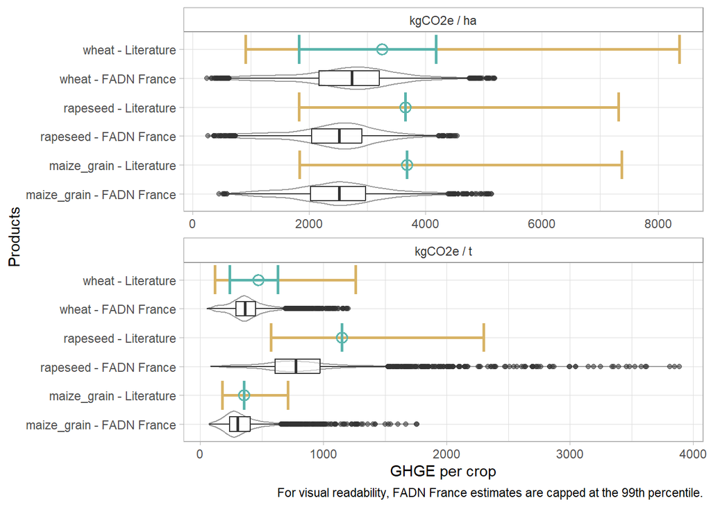

```r
# 3. Filter product and Winsorisation
tmp_plot_data <- dplyr::bind_rows(
  tmp_F2F_values0 |>
    dplyr::filter(estimate <= p99),
  tmp_lit_values0
) |>
  dplyr::filter(product_type == "Crops")


# 2. Create the plot
ggplot(tmp_plot_data) +
  # accepted range
  geom_errorbar(aes(x = product_source,
                    ymin = pmin(lit_midpoint, lit_min, na.rm = T) / 2,
                    ymax = pmax(lit_midpoint, lit_max, na.rm = T) * 2
                ), colour = "#d8b365",
                linewidth=1,width = 1,position = position_dodge(width = 0.75)) +
  # literature values
  geom_point(aes(x = product_source, y = lit_midpoint), colour = "#5ab4ac",
             shape = 1, size=3, stroke = 1, position = position_dodge(width = 0.75)) +
  # min and max
  geom_errorbar(aes(x = product_source, ymin = lit_min, ymax = lit_max), colour = "#5ab4ac",
                linewidth=1,width = 1,position = position_dodge(width = 0.75)) +
  # estimates
  geom_violin(aes(x = product_source, y = estimate, alpha = 0),
              colour = "#999999"
  ) +
  geom_boxplot(aes(x = product_source, y = estimate, alpha = 0),
               colour = "#333333", width = 0.5
  ) +
  # theme
  coord_flip() +
  facet_wrap(vars(unit_label), scales = "free",ncol = 1) +
  labs(y = "GHGE per crop",x= "Products",
       caption = "For visual readability, FADN France estimates are capped at the 99th percentile.") +
  scale_fill_viridis_d() +
  #  scale_fill_manual(values = tmp_FQS_names$colors,labels = tmp_FQS_names$labels,) +
  #  scale_colour_manual(values = tmp_FQS_names$colors,labels = tmp_FQS_names$labels) +
  theme_light() +
  theme(
    legend.position = c(0,-1),legend.direction = "horizontal",legend.title = element_blank(),
    strip.background = element_rect(fill = NA, colour = "#999999"),strip.text = element_text(color = "#333333"))
```

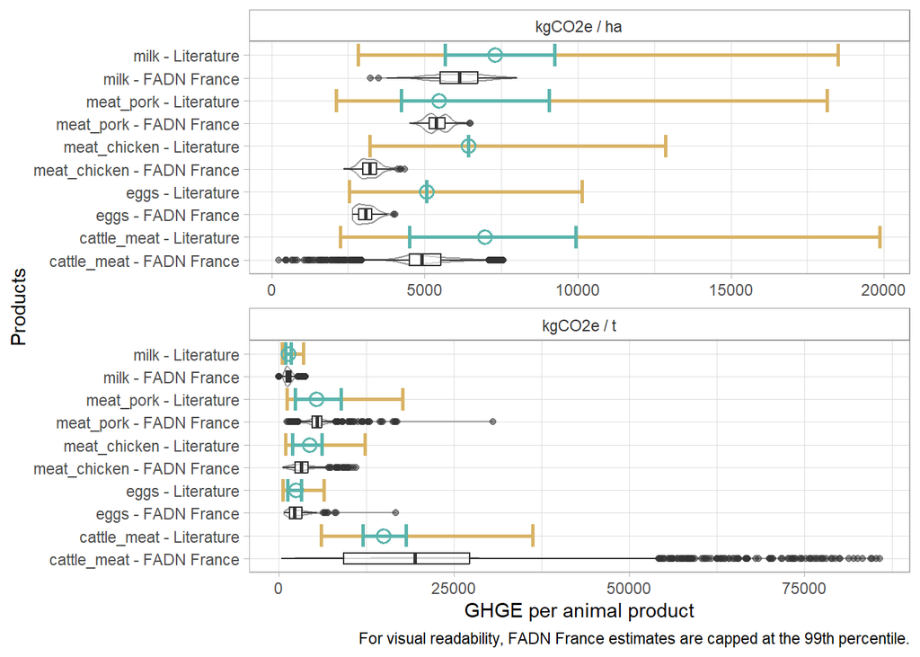

```r
# 3. Filter product and Winsorisation
tmp_plot_data <- dplyr::bind_rows(
  tmp_F2F_values0 |>
    dplyr::filter(estimate <= p99),
  tmp_lit_values0
) |>
  dplyr::filter(product_type != "Crops")


# 2. Create the plot
ggplot(tmp_plot_data) +
  # accepted range
  geom_errorbar(aes(x = product_source,
                    ymin = pmin(lit_midpoint, lit_min, na.rm = T) / 2,
                    ymax = pmax(lit_midpoint, lit_max, na.rm = T) * 2
                ), colour = "#d8b365",
                linewidth=1,width = 1,position = position_dodge(width = 0.75)) +
  # literature values
  geom_point(aes(x = product_source, y = lit_midpoint), colour = "#5ab4ac",
             shape = 1, size=3, stroke = 1, position = position_dodge(width = 0.75)) +
  # min and max
  geom_errorbar(aes(x = product_source, ymin = lit_min, ymax = lit_max), colour = "#5ab4ac",
                linewidth=1,width = 1,position = position_dodge(width = 0.75)) +
  # estimates
  geom_violin(aes(x = product_source, y = estimate, alpha = 0),
              colour = "#999999"
  ) +
  geom_boxplot(aes(x = product_source, y = estimate, alpha = 0),
               colour = "#333333", width = 0.5
  ) +
  # theme
  coord_flip() +
  facet_wrap(vars(unit_label), scales = "free",ncol = 1) +
  labs(y = "GHGE per animal product",x= "Products",
       caption = "For visual readability, FADN France estimates are capped at the 99th percentile.") +
  scale_fill_viridis_d() +
  #  scale_fill_manual(values = tmp_FQS_names$colors,labels = tmp_FQS_names$labels,) +
  #  scale_colour_manual(values = tmp_FQS_names$colors,labels = tmp_FQS_names$labels) +
  theme_light() +
  theme(
    legend.position = c(0,-1),legend.direction = "horizontal",legend.title = element_blank(),
    strip.background = element_rect(fill = NA, colour = "#999999"),strip.text = element_text(color = "#333333"))
```

```r
tmp_outliers = head(tmp_F2F_values0 |>
                      dplyr::filter(grepl("per_t", unit)) |>
                      dplyr::arrange(-estimate),
                    n = 15)

tmp_outliers
```

```
# A tibble: 15 × 12
   ID         YEAR  COUNTRY product indicator estimate unit  Category unit_label
   <chr>      <chr> <chr>   <chr>   <chr>        <dbl> <chr> <chr>    <chr>
 1 105000000… 2018  FRA     meat_p… GHGE_kgC… 1479247. kgCO… <NA>     kgCO2e / t
 2 571000000… 2020  FRA     cattle… GHGE_kgC… 1459985. kgCO… <NA>     kgCO2e / t
 3 576000000… 2021  FRA     cattle… GHGE_kgC…  709421. kgCO… <NA>     kgCO2e / t
 4 521000000… 2020  FRA     meat_p… GHGE_kgC…  681225. kgCO… <NA>     kgCO2e / t
 5 105000000… 2020  FRA     cattle… GHGE_kgC…  587175. kgCO… <NA>     kgCO2e / t
 6 521000000… 2021  FRA     meat_p… GHGE_kgC…  537774. kgCO… <NA>     kgCO2e / t
 7 594000000… 2020  FRA     cattle… GHGE_kgC…  520144. kgCO… <NA>     kgCO2e / t
 8 571000000… 2021  FRA     cattle… GHGE_kgC…  458026. kgCO… <NA>     kgCO2e / t
 9 105000000… 2019  FRA     cattle… GHGE_kgC…  454956. kgCO… <NA>     kgCO2e / t
10 521000000… 2021  FRA     cattle… GHGE_kgC…  434021. kgCO… <NA>     kgCO2e / t
11 104000000… 2020  FRA     meat_p… GHGE_kgC…  427740. kgCO… <NA>     kgCO2e / t
12 567000000… 2019  FRA     cattle… GHGE_kgC…  258788. kgCO… <NA>     kgCO2e / t
13 104000000… 2020  FRA     cattle… GHGE_kgC…  248584. kgCO… <NA>     kgCO2e / t
14 574000000… 2019  FRA     cattle… GHGE_kgC…  223699. kgCO… <NA>     kgCO2e / t
15 567000000… 2018  FRA     cattle… GHGE_kgC…  195560. kgCO… <NA>     kgCO2e / t
# ℹ 3 more variables: product_type <fct>, product_source <chr>, p99 <dbl>
```

```r
tmp_outliers_obj = m_keep_farms(
  my_object_GHGE,
  tmp_outliers
)

# compare feed
dplyr::left_join(
  my_object_GHGE@practices$herding$feed$feed_intake$total |>
    dplyr::summarise(
      DM_t_anim = mean(DM_t_anim, na.rm = TRUE),
      GE_MJ_anim = mean(GE_MJ_anim, na.rm =TRUE),
      .by = FADN_code_letter
    ),
  tmp_outliers_obj@practices$herding$feed$feed_intake$total |>
    dplyr::summarise(
      DM_t_anim_outliers = mean(DM_t_anim, na.rm = TRUE),
      GE_MJ_anim_outliers = mean(GE_MJ_anim, na.rm =TRUE),
      .by = FADN_code_letter
    )
)
```

```
# A tibble: 22 × 5
   FADN_code_letter DM_t_anim GE_MJ_anim DM_t_anim_outliers GE_MJ_anim_outliers
   <chr>                <dbl>      <dbl>              <dbl>               <dbl>
 1 LPIGFAT             0.943      17746.             1.14                21321.
 2 LPIGLET             0.0985      1861.             0.102                1919.
 3 LPIGOTH             0.967      18192.             1.14                21321.
 4 LSOWBRE             1.60       30204.             1.99                37017.
 5 LHENSLAY            0.0827      1566.             0.0380                704.
 6 LPLTRBROYL          0.0376       719.            NA                      NA
 7 LBOV1               0.704      13130.             0.861               15989.
 8 LBOV1_2F            2.66       49653.             3.39                62896.
 9 LBOV2               4.45       82537.             7.43               137750.
10 LCOWOTH             7.35      136378.            11.0                203740.
# ℹ 12 more rows
```

```r
# compare GHGE components

dplyr::left_join(
  my_object_GHGE@footprints$GHGE$GHGE_meat |>
    dplyr::summarise(dplyr::across(
      .cols = dplyr::matches("kgCO2e"),
      .fns = ~sum(.x, na.rm = TRUE)
    ),
    .by = c(output, species)) |>
    tidyr::pivot_longer(
      cols = dplyr::matches("kgCO2e")
    ),

  tmp_outliers_obj@footprints$GHGE$GHGE_meat |>
    dplyr::summarise(dplyr::across(
      .cols = dplyr::matches("kgCO2e"),
      .fns = ~sum(.x, na.rm = TRUE)
    ),
    .by = c(output, species)) |>
    tidyr::pivot_longer(
      cols = dplyr::matches("kgCO2e"),
      values_to = "value_outlier"
    ),
  by = c('output', 'species', 'name')
) |>
  dplyr::filter(!is.na(value_outlier)) |>
  dplyr::mutate(
    diff_p100 = abs(value_outlier - value) / value
  ) |>
  dplyr::arrange(-diff_p100)
```

```
# A tibble: 490 × 6
   output        species name                      value value_outlier diff_p100
   <chr>         <chr>   <chr>                     <dbl>         <dbl>     <dbl>
 1 meat_cull_cow cattle  ghg_heat_fuel_kgCO2e_li… 4.22e5          0        1
 2 meat_cull_cow cattle  ghg_heat_fuel_kgCO2e_pe… 1.01e5          0        1
 3 meat_cull_cow cattle  ghg_heat_fuel_kgCO2e_pe… 5.82e4          0        1
 4 meat_cull_cow cattle  ghg_heat_fuel_kgCO2e_pe… 4.77e4          0        1
 5 meat_cull_cow cattle  ghg_diesel_remain_kgCO2… 7.49e5          9.30     1.000
 6 meat_cull_cow cattle  ghg_elec_kgCO2e_per_ha_… 1.95e5          2.71     1.000
 7 meat_cull_cow cattle  ghg_diesel_remain_kgCO2… 4.77e5          7.94     1.000
 8 meat_cull_cow cattle  ghg_elec_kgCO2e_per_ha_… 1.18e5          2.31     1.000
 9 meat_cull_cow cattle  ghg_diesel_remain_kgCO2… 4.01e6        173.       1.000
10 meat_chicken  <NA>    ghg_heat_fuel_kgCO2e_li… 2.19e7       1010.       1.000
# ℹ 480 more rows
```

```r
tmp_data = tmp_F2F_values0 |>
                      dplyr::filter(grepl("per_ha", unit),
                                    grepl("cattle_meat", product))

tmp_quantile = quantile(tmp_data$estimate)

tmp_outliers_obj = m_keep_farms(
  my_object_GHGE,
  tmp_data |>
  dplyr::filter(estimate < tmp_quantile['25%'])
)

tmp_OK_farms <- m_keep_farms(
  my_object_GHGE,
  tmp_data |>
  dplyr::filter(estimate > tmp_quantile['75%'])
)
```

## Source of GHGE

```r
# 0. Summary table
F2F_output_ghge_compo0 |>
  summarise(
    n        = n(),
    mean     = mean(value, na.rm = TRUE),
    sd       = sd(value, na.rm = TRUE),
    min      = min(value, na.rm = TRUE),
    q25      = quantile(value, 0.25, na.rm = TRUE),
    median   = median(value, na.rm = TRUE),
    q75      = quantile(value, 0.75, na.rm = TRUE),
    max      = max(value, na.rm = TRUE),
    n_NA     = sum(is.na(value)),
    .by = c(product, unit, indicator)
  )
```

```
# A tibble: 68 × 12
   product  unit  indicator     n   mean    sd   min    q25 median    q75    max
   <chr>    <chr> <chr>     <int>  <dbl> <dbl> <dbl>  <dbl>  <dbl>  <dbl>  <dbl>
 1 wheat    kgCO… GHGE_kgC…  4484 1466.   501. 157.  1195.  1515.  1765.   5996.
 2 wheat    kgCO… GHGE_kgC…  4484  215.   167.  53.5  162.   203.   245.   8728.
 3 wheat    kgCO… GHGE_kgC…  4484  827.   381.   0    635.   864.  1042.   4423.
 4 wheat    kgCO… GHGE_kgC…  4484  123.   127.   0     82.8  115.   148.   6467.
 5 wheat    kgCO… GHGE_kgC…  4484  407.   301.   0    266.   367.   485.  10493.
 6 wheat    kgCO… GHGE_kgC…  4484   65.9  129.   0     35.3   50.1   71.8  5191.
 7 maize_g… kgCO… GHGE_kgC…  2405 1410.   441. 279.  1143.  1413.  1663.   4874.
 8 maize_g… kgCO… GHGE_kgC…  2405  206.   175.  49.3  136.   170.   224.   4479.
 9 maize_g… kgCO… GHGE_kgC…  2405  699.   325.   0    521.   716.   865.   3554.
10 maize_g… kgCO… GHGE_kgC…  2405  104.   113.   0     60.9   83.9  119.   2795.
# ℹ 58 more rows
# ℹ 1 more variable: n_NA <int>
```

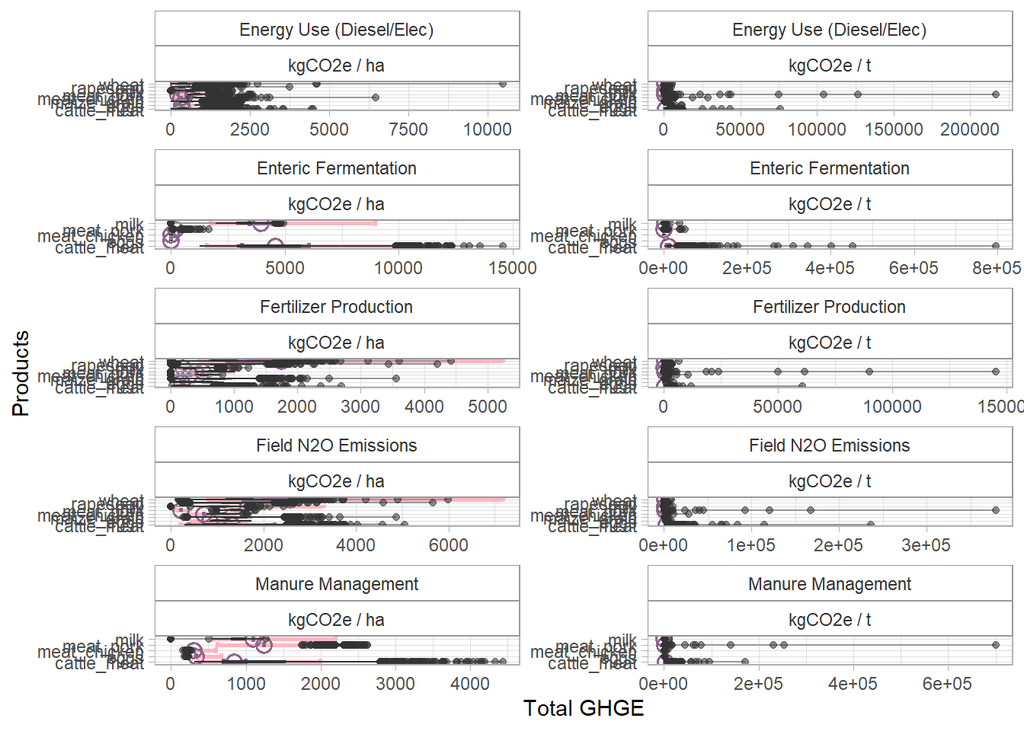

```r
# 1. Prepare data for plotting
tmp_F2F_values <- F2F_output_ghge_compo0 %>%
  # Extract the clean category name from the indicator string
  mutate(
    Category = str_extract(indicator, "(?<=__).*"),
    # Make unit names prettier for the plot labels
    unit_label = gsub("_per_"," / ", unit)
  )

tmp_lit_values <- lit_table |>
  dplyr::semi_join(
    tmp_F2F_values |>
      dplyr::select(product, unit, indicator) |>
      dplyr::distinct(),
    by = c('product', 'unit', 'indicator')
  ) |>
  # Extract the clean category name from the indicator string
  mutate(
    Category = str_extract(indicator, "(?<=__).*"),
    # Make unit names prettier for the plot labels
    unit_label = gsub("_per_"," / ", unit)
  )


# 2. Create the plot
ggplot() +
  # accepted range
  geom_errorbar(data = tmp_lit_values,
                aes(x = product,
                    ymin = pmin(lit_midpoint, lit_min, na.rm = T) / 2,
                    ymax = pmax(lit_midpoint, lit_max, na.rm = T) * 2
                ), colour = "lightpink",
                linewidth=1,width = 1,position = position_dodge(width = 0.75)) +
  # literature values
  geom_point(data = tmp_lit_values,
             aes(x = product, y = lit_midpoint), colour = "plum4",
             shape = 1, size=3, stroke = 1, position = position_dodge(width = 0.75)) +
  # min and max
  geom_errorbar(data = tmp_lit_values,
                aes(x = product, ymin = lit_min, ymax = lit_max), colour = "plum4",
                linewidth=1,width = 1,position = position_dodge(width = 0.75)) +
  # estimates
  geom_violin(data = tmp_F2F_values,
              aes(x = product, y = value, alpha = 0),
              colour = "#999999"
  ) +
  geom_boxplot(data = tmp_F2F_values,
               aes(x = product, y = value, alpha = 0),
               colour = "#333333", width = 0.25
  ) +
  # theme
  coord_flip() +
  facet_wrap(vars(Category, unit_label), scales = "free", ncol = 2) +
  labs(y = "Total GHGE",x= "Products") +
  scale_fill_viridis_d() +
  #  scale_fill_manual(values = tmp_FQS_names$colors,labels = tmp_FQS_names$labels,) +
  #  scale_colour_manual(values = tmp_FQS_names$colors,labels = tmp_FQS_names$labels) +
  theme_light() +
  theme(
    legend.position = c(0,-1),legend.direction = "horizontal",legend.title = element_blank(),
    strip.background = element_rect(fill = NA, colour = "#999999"),strip.text = element_text(color = "#333333"))
```

```r
# 1. Prepare data for plotting

tmp_plot_share <- dplyr::bind_rows(
  lit_table %>%
  # Filter only for the rows that contain the component breakdown (identified by __)
  filter(str_detect(indicator, "__")
         & unit == "kgCO2e_per_t") %>%
  # Extract the clean category name from the indicator string
  mutate(
    Category = str_extract(indicator, "(?<=__).*"),
    # Make unit names prettier for the plot labels
    unit_label = "kg CO2e / tonne"
  ) |>
    dplyr::filter(indicator %in% F2F_output_ghge_compo$indicator) |>
    dplyr::mutate(
      source = "Literature values",
      value = lit_midpoint
    ),
  F2F_output_ghge_compo %>%
  # Extract the clean category name from the indicator string
  mutate(
    Category = str_extract(indicator, "(?<=__).*"),
    # Make unit names prettier for the plot labels
    unit_label = gsub("_per_"," / ", unit),
          source = "F2F estimates",
      value = estimate
    )
) |>
  dplyr::filter(
    unit == "kgCO2e_per_t",
    grepl("wheat|milk|cattle_meat|meat_pork", product)
  )

cat(paste("Literature sources: ",paste0(unique(unlist(str_split(tmp_plot_share$lit_source, "; "))), collapse = "; ")))
```

```
Literature sources:  Bamber_2025_fig1; Bellassen_2021; Bamber_2025_sup_tab5; CAP2ER_2025_bovin_laitier; CAP2ER_2025_BV_E_JB_viande; CAP2ER_2025_BV_NE_boeufs; NA
```

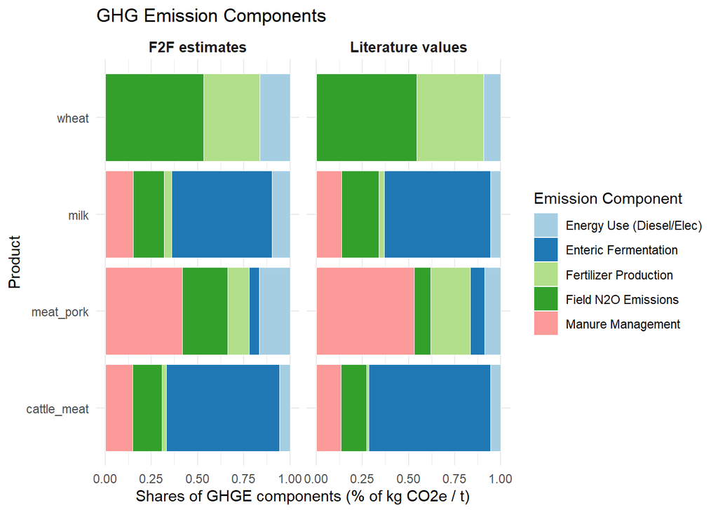

```r
# 2. Create the plot
ggplot(tmp_plot_share, aes(x = product, y = value, fill = Category)) +
  # Use stat = "identity" to plot the literal values in the table
  geom_bar(stat = "identity", position = "fill", color = "white", linewidth = 0.1) +
  # Facet by Product (rows) and Unit (columns)
  # scales = "free_y" is crucial because ha and t values are not comparable
  facet_grid(~ source) +
  # Styling
  scale_fill_brewer(palette = "Paired") + # Or use scale_fill_viridis_d()
  theme_minimal() +
  labs(
    title = "GHG Emission Components",
    #subtitle = paste("Literature sources: ",paste0(unique(unlist(str_split(tmp_plot_share$lit_source, "; "))), collapse = "; ")),
    x = "Product",
    y = "Shares of GHGE components (% of kg CO2e / t)",
    fill = "Emission Component"
  ) +
  theme(
    strip.text = element_text(face = "bold", size = 10),
    legend.position = "right",
    #axis.text.x = element_blank(), # Remove x axis text because it's redundant with facets
    axis.ticks.x = element_blank()
  ) +
  guides(fill = guide_legend(ncol = 1, title.position = "top")) +
  coord_flip()
```

# Validation

```r
comparison <- validate_against_literature(
  estimates = F2F_output,
  references = lit_table)

# TODO: check missing share concent
# TODO: check lit value for Bellassen
```

```r
comparison |>
  count(status) |>
  gt() |>
  tab_header(title = "Validation summary")
```

Validation summary

| status | n |
| --- | --- |
| ⚠️ missing | 39 |
| ✅ in range | 70 |
| ❌ out of range | 12 |

```r
comp_table = comparison |>
  dplyr::filter(!is.na(estimate)) |>
  dplyr::select(indicator, product, unit,
                lit_midpoint, lit_min, lit_max, lit_source,
                estimate, rel_deviation_pct, status) |>
  arrange(product,indicator) |>
  gt() |>
  tab_header(
    title    = "Detailed validation results",
    subtitle = paste("Estimation on France data: ",
                     paste(sort(unique(my_object_GHGE@farm$YEAR)),
                           collapse = ", "))
  ) |>
  fmt_number(columns = c(lit_midpoint, lit_min, lit_max, estimate), decimals = 1) |>
  fmt_number(columns = c(rel_deviation_pct), decimals = 1) |>
  tab_style(
    style     = cell_fill(color = "#fdd"),
    locations = cells_body(rows = status == "\U274C out of range")
  ) |>
  tab_style(
    style     = cell_fill(color = "#dfd"),
    locations = cells_body(rows = status == "\U2705 in range")
  ) |>
  tab_style(
    style     = cell_fill(color = "#ffd"),
    locations = cells_body(rows = grepl("tolerance", status))
  )

comp_table
```

Detailed validation results

Estimation on France data: 2018, 2019, 2020, 2021

| indicator | product | unit | lit_midpoint | lit_min | lit_max | lit_source | estimate | rel_deviation_pct | status |
| --- | --- | --- | --- | --- | --- | --- | --- | --- | --- |
| pseudofarm_total_CH4_kgCO2e_per_LU | Beef farms | kgCO2e_per_LU | 6,068.8 | 3,023.3 | 9,114.2 | ADEME data base | 3,406.7 | 43.9 | ✅ in range |
| pseudofarm_total_CO2_kgCO2e_per_LU | Beef farms | kgCO2e_per_LU | 2,754.7 | 1,024.3 | 4,485.0 | ADEME data base | 702.5 | 74.5 | ✅ in range |
| pseudofarm_total_N2O_kgCO2e_per_LU | Beef farms | kgCO2e_per_LU | 1,921.0 | 967.3 | 2,874.7 | ADEME data base | 1,408.3 | 26.7 | ✅ in range |
| pseudofarm_total_ghge_kgCO2e_per_LU | Beef farms | kgCO2e_per_LU | 10,670.5 | 6,202.1 | 15,138.9 | ADEME data base | 5,517.5 | 48.3 | ✅ in range |
| pseudofarm_total_CH4_kgCO2e_per_LU | Dairy farms | kgCO2e_per_LU | 4,389.4 | 3,240.5 | 5,538.2 | ADEME data base | 3,971.9 | 9.5 | ✅ in range |
| pseudofarm_total_CO2_kgCO2e_per_LU | Dairy farms | kgCO2e_per_LU | 1,697.1 | 838.7 | 2,555.6 | ADEME data base | 1,208.5 | 28.8 | ✅ in range |
| pseudofarm_total_N2O_kgCO2e_per_LU | Dairy farms | kgCO2e_per_LU | 1,292.8 | 699.0 | 1,886.5 | ADEME data base | 1,826.7 | 41.3 | ✅ in range |
| pseudofarm_total_ghge_kgCO2e_per_LU | Dairy farms | kgCO2e_per_LU | 7,370.2 | 5,173.0 | 9,567.3 | ADEME data base | 7,007.1 | 4.9 | ✅ in range |
| pseudofarm_total_CH4_kgCO2e_per_ha | Field crop farms | kgCO2e_per_ha | 43.0 | 0.0 | 241.5 | ADEME data base | 164.1 | 282.0 | ✅ in range |
| pseudofarm_total_CO2_kgCO2e_per_ha | Field crop farms | kgCO2e_per_ha | 900.0 | 29.3 | 1,770.7 | ADEME data base | 1,152.8 | 28.1 | ✅ in range |
| pseudofarm_total_N2O_kgCO2e_per_ha | Field crop farms | kgCO2e_per_ha | 1,254.3 | 494.7 | 2,013.9 | ADEME data base | 1,562.0 | 24.5 | ✅ in range |
| pseudofarm_total_ghge_kgCO2e_per_ha | Field crop farms | kgCO2e_per_ha | 2,322.5 | 951.0 | 3,694.1 | ADEME data base | 2,879.0 | 24.0 | ✅ in range |
| GHGE_kgCO2e_ha | cattle_meat | kgCO2e_per_ha | 6,962.5 | 4,496.0 | 9,931.0 | CAP2ER_2025_BV_E_JB_viande; CAP2ER_2025_BV_NE_boeufs; Extract_Agribalyse | 5,045.6 | 27.5 | ✅ in range |
| GHGE_kgCO2e_ha__Energy Use (Diesel/Elec) | cattle_meat | kgCO2e_per_ha | 355.9 | 298.1 | 413.8 | CAP2ER_2025_BV_E_JB_viande; CAP2ER_2025_BV_NE_boeufs | 442.1 | 24.2 | ✅ in range |
| GHGE_kgCO2e_ha__Enteric Fermentation | cattle_meat | kgCO2e_per_ha | 4,573.2 | 3,105.0 | 6,041.4 | CAP2ER_2025_BV_E_JB_viande; CAP2ER_2025_BV_NE_boeufs | 4,302.2 | 5.9 | ✅ in range |
| GHGE_kgCO2e_ha__Fertilizer Production | cattle_meat | kgCO2e_per_ha | 95.2 | 24.8 | 165.5 | CAP2ER_2025_BV_E_JB_viande; CAP2ER_2025_BV_NE_boeufs | 213.5 | 124.3 | ✅ in range |
| GHGE_kgCO2e_ha__Field N2O Emissions | cattle_meat | kgCO2e_per_ha | 1,303.5 | 372.6 | 2,234.5 | CAP2ER_2025_BV_E_JB_viande; CAP2ER_2025_BV_NE_boeufs | 1,136.0 | 12.9 | ✅ in range |
| GHGE_kgCO2e_ha__Manure Management | cattle_meat | kgCO2e_per_ha | 844.3 | 695.5 | 993.1 | CAP2ER_2025_BV_E_JB_viande; CAP2ER_2025_BV_NE_boeufs | 1,122.6 | 33.0 | ✅ in range |
| GHGE_kgCO2e_t | cattle_meat | kgCO2e_per_t | 14,866.7 | 12,000.0 | 18,100.0 | CAP2ER_2025_BV_E_JB_viande; CAP2ER_2025_BV_NE_boeufs; Extract_Agribalyse | 22,200.9 | 49.3 | ✅ in range |
| GHGE_kgCO2e_t__Energy Use (Diesel/Elec) | cattle_meat | kgCO2e_per_t | 850.0 | 500.0 | 1,200.0 | CAP2ER_2025_BV_E_JB_viande; CAP2ER_2025_BV_NE_boeufs | 1,479.5 | 74.1 | ✅ in range |
| GHGE_kgCO2e_t__Enteric Fermentation | cattle_meat | kgCO2e_per_t | 9,900.0 | 7,300.0 | 12,500.0 | CAP2ER_2025_BV_E_JB_viande; CAP2ER_2025_BV_NE_boeufs | 16,320.7 | 64.9 | ✅ in range |
| GHGE_kgCO2e_t__Fertilizer Production | cattle_meat | kgCO2e_per_t | 150.0 | 100.0 | 200.0 | CAP2ER_2025_BV_E_JB_viande; CAP2ER_2025_BV_NE_boeufs | 607.7 | 305.1 | ❌ out of range |
| GHGE_kgCO2e_t__Field N2O Emissions | cattle_meat | kgCO2e_per_t | 2,100.0 | 1,500.0 | 2,700.0 | CAP2ER_2025_BV_E_JB_viande; CAP2ER_2025_BV_NE_boeufs | 4,232.2 | 101.5 | ✅ in range |
| GHGE_kgCO2e_t__Manure Management | cattle_meat | kgCO2e_per_t | 2,000.0 | 1,200.0 | 2,800.0 | CAP2ER_2025_BV_E_JB_viande; CAP2ER_2025_BV_NE_boeufs | 3,928.9 | 96.4 | ✅ in range |
| DMI | dairy_cows | kg / head / day | 16.0 | 8.0 | 24.0 | Flachowsky_2002 | 8.1 | 49.4 | ✅ in range |
| GE | dairy_cows | MJ / head / day | 308.0 | NA | NA | Bellassen_2021 | 413.6 | 34.3 | ✅ in range |
| Nex | dairy_cows | kg N / head / year | 115.9 | NA | NA | UNFCCC_2020 | 143.5 | 23.8 | ✅ in range |
| first_calving_age | dairy_cows | month | 30.0 | 27.0 | 32.0 | CAP2ER_2025 | 30.4 | 1.2 | ✅ in range |
| renewal_rate | dairy_cows | percent | 36.0 | 32.0 | 36.0 | CAP2ER_2025 | 22.4 | 37.7 | ✅ in range |
| share_concent | dairy_cows | percent | 20.0 | 0.0 | 40.0 | Flachowsky_2002 | 25.9 | 29.3 | ✅ in range |

[output cut: 52 more lines]

```r
gtsave(comp_table, filename = paste0("F2F_comp_lit_summary_",Sys.Date(),".html"))
gtsave(comp_table, filename = paste0("F2F_comp_lit_summary_",Sys.Date(),".docx"))
```

[figure not shown]

Figure 1: Relative deviation from literature midpoint by indicator

```r
library(ggplot2)

comparison |>
  filter(!is.na(estimate)) |>
  ggplot(aes(x = reorder(paste(indicator, product, sep = " — "),
                         rel_deviation_pct),
             y = rel_deviation_pct,
             fill = status)) +
  geom_col() +
  geom_hline(aes(yintercept = 50), linetype = "dashed", colour = "red") +
  scale_fill_discrete(direction = -1) +
  coord_flip() +
  labs(x = NULL, y = "Relative deviation from midpoint (%)") +
  theme_minimal()
```

# Checks

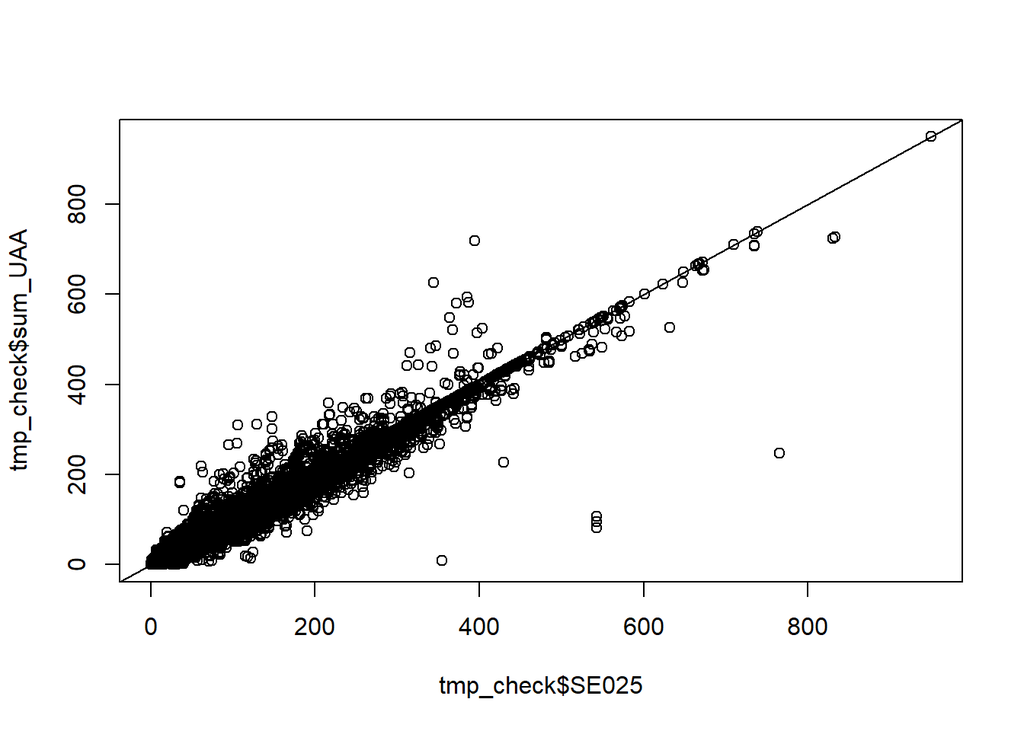

```r
object = my_object_GHGE

id_cols = object@traceability$id_cols

tmp_tot_UAA = object@farm |>
  dplyr::select(dplyr::all_of(id_cols),
                SE025)

tmp_sum_UAA = object@crop |>
  #dplyr::filter(!grepl("CTOT",FADN_code_letter)) |>
  dplyr::summarise(
    sum_UAA = sum(area_ha, na.rm = TRUE),
    .by = dplyr::all_of(id_cols)
  )

tmp_check = dplyr::left_join(
  tmp_tot_UAA,
  tmp_sum_UAA,
  by = id_cols
)

plot(tmp_check$SE025, tmp_check$sum_UAA)
abline(0,1)
```

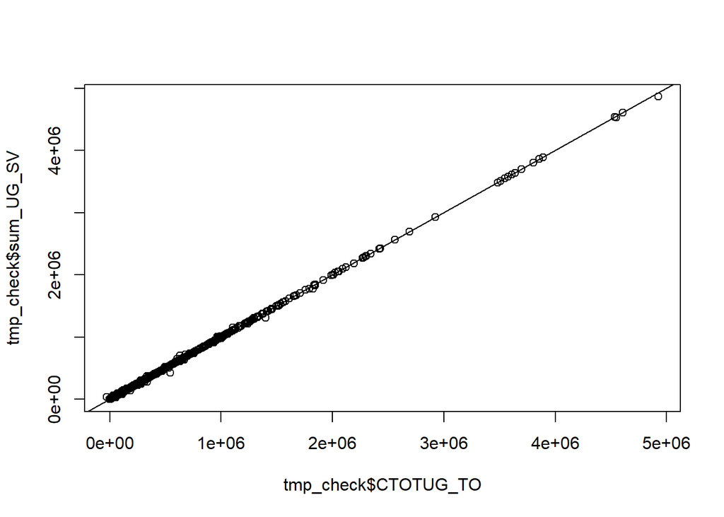

```r
load("C:/Users/srhuet/OneDrive/Research/GitHub/FADN2Footprint/data_raw/raw_FADN_FRA_18_21.RData")

object = my_object_GHGE

id_cols = object@traceability$id_cols

tmp_tot_UG = my_FADN_data |>
  dplyr::select(dplyr::all_of(id_cols),
                CTOTUG_TO) |>
  dplyr::mutate(ID = as.character(ID),
                YEAR = as.character(YEAR))

tmp_sum_UG = object@crop |>
  dplyr::filter(grepl("UG$",FADN_code_letter)) |>
  dplyr::summarise(
    sum_UG_TO = sum(TO, na.rm = TRUE),
    sum_UG_SV = sum(SV, na.rm = TRUE),
    .by = dplyr::all_of(id_cols)
  )

tmp_check = dplyr::left_join(
  tmp_tot_UG,
  tmp_sum_UG,
  by = id_cols
)

plot(tmp_check$CTOTUG_TO, tmp_check$sum_UG_SV)
abline(0,1)
```

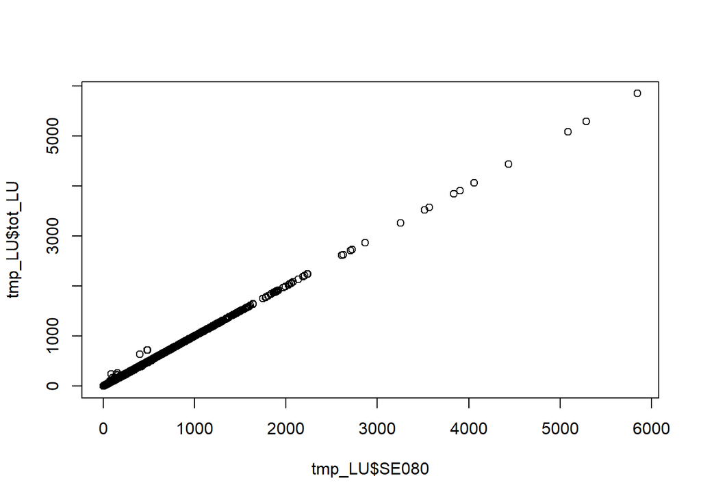

```r
object = my_object_GHGE

id_cols = object@traceability$id_cols


tmp_farm_LU = object@farm |>
  dplyr::select(dplyr::all_of(id_cols),
                SE080)

tmp_herd_LU = object@herd |>
  dplyr::summarise(
    tot_LU = sum(ALU, na.rm = T),
    .by =  dplyr::all_of(id_cols)
  )

tmp_LU = dplyr::left_join(
  tmp_farm_LU,
  tmp_herd_LU,
  by = id_cols
)

plot(tmp_LU$SE080, tmp_LU$tot_LU)
```

## Meat production

I want to compare our estimation for meat production to EUROSTAT price : https://ec.europa.eu/eurostat/databrowser/view/apri_ap_anouta__custom_21870211/default/table Les prix pour la France sont bizarre : on est ~360€ pour 100kg et par tête pour les génisses alors qu’en Espagne par exemple, on est à 285€ pour 100 kg (donc 2850€/t) et 1200€ par tête le rendement dans agribalyse est de 1/22e-4=450 kg/ha vs 7.2/15*10^3 = 480 kg/ha dans CAP2ER

```r
# Heiffers

tmp_heif = tmp_object_beef@output$meat |>
  dplyr::filter(FADN_code_letter == "LHEIFFAT")

cat("Average weight for heiffers: ",
    mean(tmp_heif$prod_t / tmp_heif$sales_nb, na.rm = TRUE)," t/head")
```

```
Average weight for heiffers:  0.4409379  t/head
```

```r
cat("\n")
```

```r
cat("Mean price for heiffer: ",
    mean(tmp_heif$sales_e / tmp_heif$sales_nb, na.rm = TRUE)," €/head and ",
    mean(tmp_heif$sales_e / tmp_heif$prod_t, na.rm = TRUE)," €/t")
```

```
Mean price for heiffer:  1512.5  €/head and  3430.189  €/t
```

```r
cat("\n")
```

```r
cat("\n")
```

```r
cat("\nOn average, beef farms sell ",
    (mean(tmp_object_beef@herd |>
            #dplyr::filter(grepl("LHEIF",FADN_code_letter)) |>
            dplyr::pull(share_SSN),
          na.rm = T))*100,"% of their animals for slaughter")
```

```
On average, beef farms sell  61.58834 % of their animals for slaughter
```

I want to compare our liveweight production per livestock units to those reported in CAP2ER => OK, eventhough we overestimate veal live weight

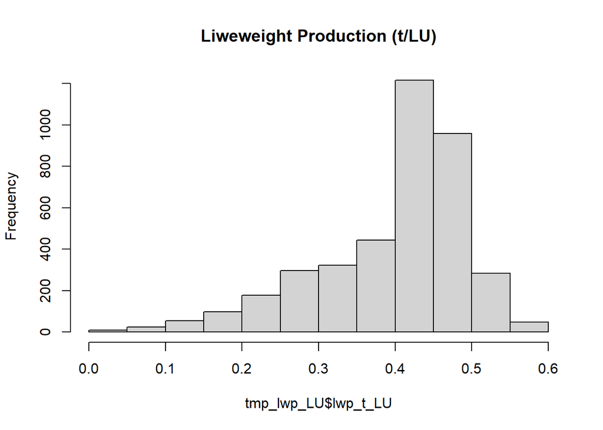

```r
object = tmp_object_beef

tmp_lwp <- object@output$meat |>
  dplyr::filter(grepl("meat", output) & species == "cattle") |>
  dplyr::summarise(
    LWP_t = sum(prod_t, na.rm = TRUE),
    .by = dplyr::all_of(id_cols)
  )

tmp_sold_LU = object@herd |>
  dplyr::filter(species == "cattle") |>
  dplyr::summarise(
    tot_LU = sum(SN * livestock_unit_coef, na.rm = T),
    .by =  dplyr::all_of(id_cols)
  )

tmp_lwp_LU <- dplyr::left_join(
  tmp_lwp,
  tmp_sold_LU,
  by = id_cols
) |>
  dplyr::mutate(
    lwp_t_LU = LWP_t / tot_LU
  )

hist(tmp_lwp_LU$lwp_t_LU, main = "Liweweight Production (t/LU)")
```

```r
quantile(tmp_lwp_LU$lwp_t_LU)
```

```
        0%        25%        50%        75%       100%
0.04006993 0.34997468 0.43529124 0.45889267 0.57552340
```

```r
mean(tmp_lwp_LU$lwp_t_LU)
```

```
[1] 0.399804
```

```r
object@herd |> filter(ID == "52100000050798")
```

```
# A tibble: 20 × 26
   ID       YEAR  COUNTRY FADN_code_letter    AN    PN    PV    SN    SV      TO
   <chr>    <chr> <chr>   <chr>            <dbl> <dbl> <dbl> <dbl> <dbl>   <dbl>
 1 5210000… 2018  FRA     LBOV1_2F           2.5     0     0     5  5667  8203.
 2 5210000… 2018  FRA     LBOV1            237       0     0   560 54145 54145
 3 5210000… 2018  FRA     LBOV2              0.5     1  1350     1   650  -700
 4 5210000… 2018  FRA     LCOWOTH           20       0     0     0     0  -115.
 5 5210000… 2018  FRA     LHEIFFAT           3.5     0     0     0     0 -3687.
 6 5210000… 2019  FRA     LBOV1_2F           8       0     0     0     0   -14.8
 7 5210000… 2019  FRA     LBOV1            234.      0     0   560 54570 54148
 8 5210000… 2019  FRA     LBOV2              0.5     1  1600     0     0  -382.
 9 5210000… 2019  FRA     LCOWOTH           17.5     0     0     0     0 -4673.
10 5210000… 2019  FRA     LHEIFFAT           4.5     0     0     0     0  5892.
11 5210000… 2020  FRA     LBOV1_2F           7.5     0     0     6  6464  5484.
12 5210000… 2020  FRA     LBOV1            232       0     0     7  4404  4826
13 5210000… 2020  FRA     LBOV2              0.5     0     0     1  1114  -139.
14 5210000… 2020  FRA     LCOWOTH           15       0     0     0     0  -113.
15 5210000… 2020  FRA     LHEIFFAT           6.5     0     0     0     0 -1319.
16 5210000… 2021  FRA     LBOV1_2F          10       0     0     0     0  5061.
17 5210000… 2021  FRA     LBOV1            232       0     0     7  5775  4931
18 5210000… 2021  FRA     LBOV2              0.5     1  1700     0     0  -466.
19 5210000… 2021  FRA     LCOWOTH           14       0     0     4  6018  3975.
20 5210000… 2021  FRA     LHEIFFAT           6.5     0     0     4  5686  6058.
# ℹ 16 more variables: livestock_unit_coef <dbl>, species <chr>, ALU <dbl>,
#   ON <dbl>, CN <dbl>, Qobs <dbl>, SSN <dbl>, SSV <dbl>, SRN <dbl>, SRV <dbl>,
#   NUTS2 <chr>, TF14 <int>, Country_ISO_3166_1_A3 <chr>, share_SSN <dbl>,
#   share_SRN <dbl>, complete_sales <lgl>
```

```r
object@output$meat |> filter(ID == "52100000050798")
```

```
# A tibble: 10 × 15
   ID      YEAR  COUNTRY FADN_code_letter output species sales_nb prod_t sales_t
   <chr>   <chr> <chr>   <chr>            <chr>  <chr>      <dbl>  <dbl>   <dbl>
 1 521000… 2018  FRA     LBOV1_2F         meat_… cattle     0.318  0.140   0.140
 2 521000… 2018  FRA     LBOV1            meat_… cattle   218.    96.2    96.2
 3 521000… 2018  FRA     LBOV2            meat_… cattle     1.000  0.441   0.441
 4 521000… 2019  FRA     LBOV1            meat_… cattle   218.    96.2    96.2
 5 521000… 2020  FRA     LBOV1_2F         meat_… cattle     0.382  0.168   0.168
 6 521000… 2020  FRA     LBOV1            meat_… cattle     2.73   1.20    1.20
 7 521000… 2020  FRA     LBOV2            meat_… cattle     1.000  0.441   0.441
 8 521000… 2021  FRA     LBOV1            meat_… cattle     2.73   1.20    1.20
 9 521000… 2021  FRA     LCOWOTH          meat_… cattle     3.45   1.52    1.52
10 521000… 2021  FRA     LHEIFFAT         meat_… cattle     4.00   1.76    1.76
# ℹ 6 more variables: sales_e <dbl>, output_e <dbl>, yield_t_sales_nb <dbl>,
#   prop_sales_Qobs <dbl>, yield_t_Qobs <dbl>, yield_e_Qobs <dbl>
```

```r
my_FADN_data |> filter(ID == "52100000050798") |> dplyr::select(dplyr::all_of(id_cols),dplyr::matches("LBOV")) |> tidyr::pivot_longer(cols = -dplyr::all_of(id_cols))
```

```
# A tibble: 128 × 5
        ID  YEAR COUNTRY name         value
     <dbl> <int> <chr>   <chr>        <dbl>
 1 5.21e13  2018 FRA     LBOV0_AN_X     0
 2 5.21e13  2018 FRA     LBOV0_PN_X     0
 3 5.21e13  2018 FRA     LBOV0_PV_X     0
 4 5.21e13  2018 FRA     LBOV0_SN_X     0
 5 5.21e13  2018 FRA     LBOV1_2F_AN    2.5
 6 5.21e13  2018 FRA     LBOV1_2F_PN    0
 7 5.21e13  2018 FRA     LBOV1_2F_PV    0
 8 5.21e13  2018 FRA     LBOV1_2F_SN    5
 9 5.21e13  2018 FRA     LBOV1_2F_SV 5667
10 5.21e13  2018 FRA     LBOV1_2F_TO 8203.
# ℹ 118 more rows
```

## Eggs

```r
# LHENSLAY

tmp_LU <- tmp_object_eggs@herd |>
  dplyr::filter(FADN_code_letter == "LHENSLAY")


tmp_prod <- tmp_object_eggs@output$other_herd_products |>
  dplyr::filter(grepl("PEGG", FADN_code_letter_output)) |>
  dplyr::summarise(
    prod_t = sum(prod_t, na.rm = T),
    .by = c(dplyr::all_of(id_cols), output)
  )

tmp_yield <- dplyr::left_join(
  tmp_LU, tmp_prod,
  by = id_cols
) |>
  dplyr::mutate(
    yield = prod_t / Qobs
  )

quantile(tmp_yield$yield)
```

```
         0%         25%         50%         75%        100%
0.002330097 0.012885048 0.015852588 0.017494737 0.022718949
```

## Feed

```r
object = my_object_GHGE
id_cols = my_object_GHGE@traceability$id_cols

th_feed <- f_feed_theo_ration(object)

# create the "would-be" allocation exactly like f_feed_offfarm does (uses traceability id cols)
feed_purchased_qty <- object@input |>
  # Retrieve farm purchases values for concentrate and rough feed
  dplyr::select(dplyr::all_of(id_cols),
                dplyr::matches("feed_purch")) |>
  ## Purchased concentrated feedstuffs for grazing stock (equines, ruminants) Value in EUR
  ##feed_purch_concent_graz = IGRFEDCNCTRPUR_V,
  ## Purchased coarse fodder for grazing stock (equines, ruminants) Value in EUR
  ##feed_purch_rough_graz = IGRFEDCRSPUR_V,
  ## Purchased feedstuffs for pigs Value in EUR
  ##feed_purch_concent_pigs = IPIGFEDPUR_V,
  ## Purchased feedstuffs for poultry and other small animals Value in EUR
  ##feed_purch_concent_poultry = IPLTRFEDPUR_V,
  tidyr::pivot_longer(cols = tidyselect::matches("feed_purch"),
                      names_to = "feed_var",
                      values_to = "feed_purch_value") |>
  dplyr::filter(feed_purch_value >0) |>
  dplyr::mutate(
    feed_type = dplyr::case_when(
      feed_var == "feed_purch_rough_graz" ~ "feed_rough",
      .default = "feed_concent"
    ),
    species = dplyr::case_when(
      feed_var %in% c("feed_purch_concent_graz","feed_purch_rough_graz") ~ "grazing",
      feed_var == "feed_purch_concent_pigs" ~ "swine",
      feed_var == "feed_purch_concent_poultry" ~ "poultry"
    )
  ) |>
  #filter(feed_purch_value >0) |> # keep null purchases for traceability
  # Add theoretical values
  dplyr::left_join(th_feed$th_feed_value |>
                     dplyr::select(dplyr::all_of(id_cols),
                                   species, FADN_code_letter,
                                   feed_type, Sailley_feed,
                                   th_crop_value_p100_feed_type, euros_t),
                   by = c(id_cols,"feed_type","species")) |>
  # Estimate share of purchased feed value per livestock category and per crop
  dplyr::mutate(
    feed_purch_value_share = feed_purch_value * th_crop_value_p100_feed_type
  ) |>
  # Convert estimated value in ton
  dplyr::mutate(
    feed_purch_t_livcat = feed_purch_value_share / euros_t
  )

# summary per feed_var
tmp_comp <- feed_purchased_qty |>
  dplyr::summarise(
    total_input = mean(feed_purch_value, na.rm=TRUE),
    total_allocated = sum(feed_purch_value_share, na.rm=TRUE),
    n_rows = n(),
    #n_unallocated = sum(is.na(feed_purch_value_share)),
    #.by = feed_var
    .by = c(dplyr::all_of(id_cols), species, feed_type)
  ) |>
  dplyr::mutate(
    diff_p100 = abs(total_allocated - total_input) / total_input,
    diff = ifelse(round(diff_p100,5) > 0, TRUE, FALSE))

table(tmp_comp$diff)
```

```
FALSE  TRUE
21874   476
```

```r
# see if livestock corresponding to feed
tmp_comp |>
  dplyr::filter(diff) |>
  dplyr::left_join(
    object@herd |>
      #dplyr::mutate(
      #    species = case_when(
      #        species %in% c("cattle","sheep","goats","horse") ~ "grazing",
      #        .default = species
      #    )
      #) |>
      dplyr::summarise(
        Qobs = sum(Qobs),
        .by = c(dplyr::all_of(id_cols), species)
      ) |>
      tidyr::pivot_wider(names_from = species, values_from = Qobs),
    #by = c(id_cols, 'species')
    by = c(id_cols)
  ) #|> View()
```

```
# A tibble: 476 × 17
   ID         YEAR  COUNTRY species feed_type total_input total_allocated n_rows
   <chr>      <chr> <chr>   <chr>   <chr>           <dbl>           <dbl>  <int>
 1 515000000… 2018  FRA     poultry feed_con…         982               0      1
 2 515000000… 2018  FRA     poultry feed_con…         332               0      1
 3 515000000… 2018  FRA     poultry feed_con…        6047               0      1
 4 515000000… 2018  FRA     poultry feed_con…       15441               0      1
 5 515000000… 2018  FRA     poultry feed_con…         265               0      1
 6 515000000… 2018  FRA     poultry feed_con…         174               0      1
 7 515000000… 2018  FRA     poultry feed_con…         724               0      1
 8 515000000… 2018  FRA     poultry feed_con…         427               0      1
 9 565000000… 2018  FRA     poultry feed_con…          37               0      1
10 565000000… 2018  FRA     poultry feed_con…         229               0      1
# ℹ 466 more rows
# ℹ 9 more variables: diff_p100 <dbl>, diff <lgl>, sheep <dbl>, cattle <dbl>,
#   goats <dbl>, poultry <dbl>, others <dbl>, swine <dbl>, horse <dbl>
```

Some farms purchase poultry feed but do not have poultry (some do not have livestock at all sometimes)

## Heating fuels

```r
semi_join(
  my_object_GHGE@footprints$GHGE$GHGE_herd |>
    dplyr::summarise(ghg_heat_fuel_kgCO2e_livcat = sum(ghg_heat_fuel_kgCO2e_livcat, na.rm = T),
                     .by = dplyr::all_of(id_cols)) |>
    dplyr::filter(ghg_heat_fuel_kgCO2e_livcat == 0),
  my_object_GHGE@input |> dplyr::filter(heating_fuels_l >0)
) #|> View()
```

```
# A tibble: 292 × 4
   ID            YEAR  COUNTRY ghg_heat_fuel_kgCO2e_livcat
   <chr>         <chr> <chr>                         <dbl>
 1 5610000005933 2018  FRA                               0
 2 5640000001924 2018  FRA                               0
 3 5640000001928 2018  FRA                               0
 4 5640000001921 2018  FRA                               0
 5 5640000001370 2018  FRA                               0
 6 5640000001998 2018  FRA                               0
 7 5680000005992 2018  FRA                               0
 8 5670000003311 2018  FRA                               0
 9 5670000003901 2018  FRA                               0
10 5670000003962 2018  FRA                               0
# ℹ 282 more rows
```

```r
tmp_farms = semi_join(
  my_object_GHGE@footprints$GHGE$GHGE_herd |>
    dplyr::summarise(ghg_heat_fuel_kgCO2e_livcat = sum(ghg_heat_fuel_kgCO2e_livcat, na.rm = T),
                     .by = dplyr::all_of(id_cols)) |>
    dplyr::filter(ghg_heat_fuel_kgCO2e_livcat == 0),
  my_object_GHGE@input |> dplyr::filter(heating_fuels_l >0)
) |>
  dplyr::select(dplyr::all_of(my_object_GHGE@traceability$id_cols))

tmp_obbj = m_keep_farms(my_object_GHGE, tmp_farms)

tmp_econ_alloc = f_output_econ_alloc(tmp_obbj)

summary(tmp_econ_alloc$all_outputs)
```

```
      ID                YEAR             COUNTRY          FADN_code_letter
 Length:798         Length:798         Length:798         Length:798
 Class :character   Class :character   Class :character   Class :character
 Mode  :character   Mode  :character   Mode  :character   Mode  :character




    output            species              prod_t            sales_t
 Length:798         Length:798         Min.   :   0.012   Min.   :   0.00
 Class :character   Class :character   1st Qu.:  13.361   1st Qu.:   0.00
 Mode  :character   Mode  :character   Median :  43.431   Median :  16.94
                                       Mean   : 104.111   Mean   :  80.44
                                       3rd Qu.: 106.694   3rd Qu.:  78.05
                                       Max.   :1912.160   Max.   :1912.16
                                                          NA's   :7
    sales_e          output_e          yield            activity
 Min.   :     0   Min.   :     0   Min.   : 0.01812   Length:798
 1st Qu.:     0   1st Qu.:     0   1st Qu.: 2.36943   Class :character
 Median :  6258   Median :  6952   Median : 4.82965   Mode  :character
 Mean   : 20248   Mean   : 20445   Mean   : 7.51871
 3rd Qu.: 20456   3rd Qu.: 20672   3rd Qu.: 7.22888
 Max.   :553150   Max.   :560377   Max.   :95.70748
                                   NA's   :7
   farm_use_e       TO_e           sales_nb     yield_t_sales_nb
 Min.   :0     Min.   :     0   Min.   :51612   Min.   :0.00191
 1st Qu.:0     1st Qu.:     0   1st Qu.:52342   1st Qu.:0.00191
 Median :0     Median :  6258   Median :53071   Median :0.00191
 Mean   :0     Mean   : 20248   Mean   :63405   Mean   :0.00191
 3rd Qu.:0     3rd Qu.: 20456   3rd Qu.:69302   3rd Qu.:0.00191
 Max.   :0     Max.   :553150   Max.   :85532   Max.   :0.00191
 NA's   :788                    NA's   :795     NA's   :795
 prop_sales_Qobs  yield_t_Qobs      yield_e_Qobs    FADN_code_letter_output
 Min.   :1.970   Min.   :0.00376   Min.   : 8.661   Length:798
 1st Qu.:1.998   1st Qu.:0.00381   1st Qu.: 9.275   Class :character
 Median :2.026   Median :0.00387   Median : 9.889   Mode  :character
 Mean   :2.332   Mean   :0.00445   Mean   :11.902
 3rd Qu.:2.513   3rd Qu.:0.00480   3rd Qu.:13.523
 Max.   :3.001   Max.   :0.00573   Max.   :17.155
 NA's   :795     NA's   :795       NA's   :795
      Qobs       sum_sales_e_farm sum_output_e_farm econ_alloc_ratio_farm
 Min.   :  5.0   Min.   :     0   Min.   :     0    Min.   :0.000000
 1st Qu.:177.2   1st Qu.: 22208   1st Qu.: 29303    1st Qu.:0.009883
 Median :200.2   Median : 69284   Median : 70450    Median :0.131234
 Mean   :184.0   Mean   :105424   Mean   :108209    Mean   :0.217087
 3rd Qu.:212.0   3rd Qu.:134005   3rd Qu.:141490    3rd Qu.:0.318758
 Max.   :313.0   Max.   :749898   Max.   :764118    Max.   :1.000000
 NA's   :792                                        NA's   :84
```

```r
tmp_econ_alloc$all_outputs #|> View()
```

```
# A tibble: 798 × 24
   ID      YEAR  COUNTRY FADN_code_letter output species  prod_t sales_t sales_e
   <chr>   <chr> <chr>   <chr>            <chr>  <chr>     <dbl>   <dbl>   <dbl>
 1 561000… 2018  FRA     CCEROTH          crop   cereal  1.62e+1    16.2    3557
 2 561000… 2018  FRA     CRAPE            crop   oilsee… 7.23e+1    72.3   24864
 3 561000… 2018  FRA     CRG              crop   grassl… 3.48e-1     0         0
 4 561000… 2018  FRA     CSUGBT           crop   root_v… 1.47e+3  1472.    31745
 5 561000… 2018  FRA     CWHTC            crop   cereal  2.31e+2   231.    40123
 6 564000… 2018  FRA     CBRL             crop   cereal  6.75e+1    67.5    9492
 7 564000… 2018  FRA     CGRSTMP          crop   <NA>    1.73e+1     0         0
 8 564000… 2018  FRA     CRAPE            crop   oilsee… 2.6 e+1    26      9065
 9 564000… 2018  FRA     CWHTC            crop   cereal  8.84e+1    88.4   14797
10 564000… 2018  FRA     CRG              crop   grassl… 5.50e+0     0         0
# ℹ 788 more rows
# ℹ 15 more variables: output_e <dbl>, yield <dbl>, activity <chr>,
#   farm_use_e <dbl>, TO_e <dbl>, sales_nb <dbl>, yield_t_sales_nb <dbl>,
#   prop_sales_Qobs <dbl>, yield_t_Qobs <dbl>, yield_e_Qobs <dbl>,
#   FADN_code_letter_output <chr>, Qobs <dbl>, sum_sales_e_farm <dbl>,
#   sum_output_e_farm <dbl>, econ_alloc_ratio_farm <dbl>
```

## Farms with zero GHGE

```r
object = my_object_GHGE
id_cols = object@traceability$id_cols

tmp_obj_farms_zero <- m_keep_farms(
  object,
  object@footprints$GHGE$GHGE_farm |>
    dplyr::filter(is.na(farm_total_ghge_kgCO2e ) | farm_total_ghge_kgCO2e  == 0)
)

table(tmp_obj_farms_zero@farm$TF14)
```

```
50
89
```

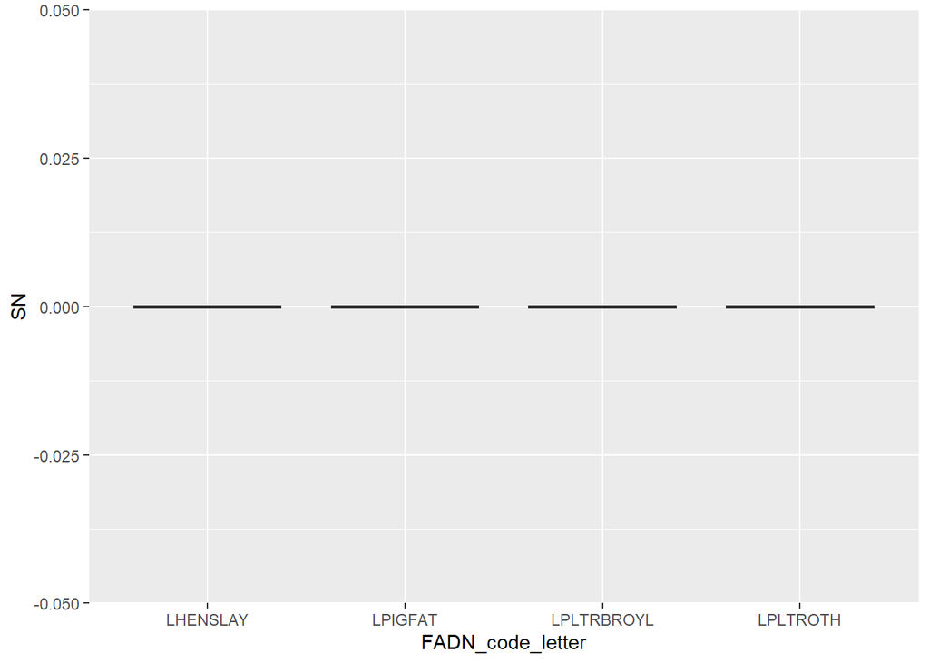

```r
tmp_obj_farms_zero@herd |>
  ggplot() +
  aes(x = FADN_code_letter,
      y = SN) +
  geom_boxplot()
```

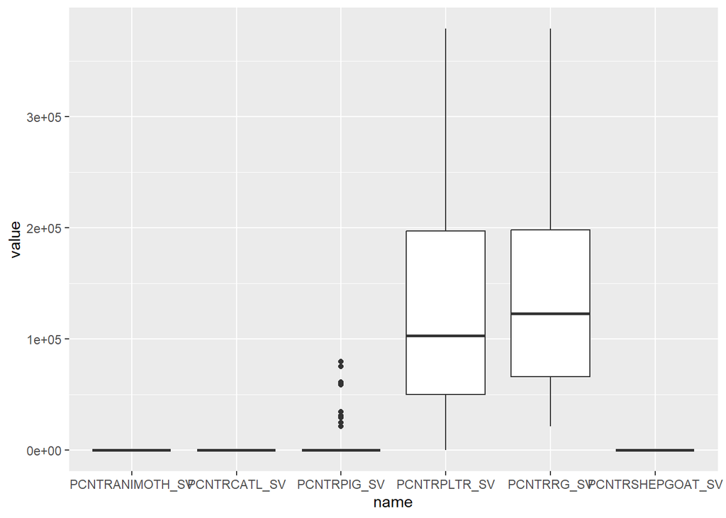

```r
my_FADN_data |>
  dplyr::select(dplyr::all_of(id_cols),
                dplyr::matches("PCNT")) |>
  dplyr::mutate(ID = as.character(ID),
                YEAR = as.character(YEAR)) |>
  dplyr::semi_join(tmp_obj_farms_zero@farm,
                   by = id_cols) |>
  tidyr::pivot_longer(cols = -dplyr::all_of(id_cols)) |>
  dplyr::filter(grepl("_SV$", name))|>
  ggplot() +
  aes(x = name,
      y = value) +
  geom_boxplot()
```

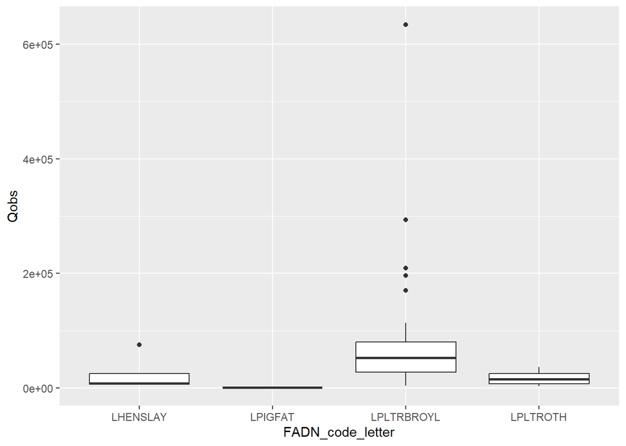

```r
tmp_obj_farms_zero@herd |>
  ggplot() +
  aes(x = FADN_code_letter,
      y = Qobs) +
  geom_boxplot()
```